# Statlog (Image Segmentation)

## Progetto di Matematica per l'Intelligenza Artificiale

Politecnico di Torino · Corso di Laurea in Matematica per l'Ingegneria

**Studente**: Angelamaria Colucci  
**Matricola**: s323606

## Sommario

0. Setup e import
1. Introduzione e descrizione del dataset
2. Analisi esplorativa dei dati (EDA)
3. Preparazione dei dati
4. Principal Component Analysis (PCA)
5. Fisher Discriminant Analysis (FDA / MDA multiclasse)
6. Linear Discriminant Analysis (LDA) e Quadratic Discriminant Analysis (QDA)
7. Support Vector Machine (lineare, kernel RBF/polinomiale, grid search)
8. Multi-Layer Perceptron (MLP)
9. Confronto finale dei modelli
10. Conclusioni

Appendice — Formule esplicite  
Bibliografia essenziale

## 0. Setup e import

```python
import os
import numpy as np
import pandas as pd
import matplotlib
import matplotlib.pyplot as plt
from IPython.display import display
import warnings
warnings.filterwarnings('ignore')  # silenzia i deprecation warning di matplotlib/sklearn

from sklearn.preprocessing import StandardScaler, LabelEncoder
from sklearn.model_selection import train_test_split, GridSearchCV, StratifiedKFold
from sklearn.decomposition import PCA
from sklearn.discriminant_analysis import LinearDiscriminantAnalysis as LDA
from sklearn.discriminant_analysis import QuadraticDiscriminantAnalysis as QDA
from sklearn.svm import LinearSVC, SVC
from sklearn.neural_network import MLPClassifier
from sklearn.metrics import (accuracy_score, precision_score, recall_score,
                              f1_score, confusion_matrix, classification_report)
from FisherDA import MultipleFisherDiscriminantAnalysis as MDA

plt.rcParams['figure.figsize'] = (12, 8)
```

## 1. Introduzione e descrizione del dataset

### 1.1 Contesto

Il dataset analizzato è **Statlog (Image Segmentation)** ([UCI #147](https://archive.ics.uci.edu/dataset/147/statlog+image+segmentation)), raccolto nel **novembre 1990** dal Vision Group della **University of Massachusetts**. È un classico benchmark di *low-level image understanding* utilizzato negli anni '90 e 2000 come termine di paragone per algoritmi di classificazione di pixel, in epoca precedente alle reti neurali convoluzionali.

Il dataset è stato costruito a partire da **7 fotografie outdoor** segmentate manualmente: un operatore ha colorato ogni pixel di ciascuna immagine attribuendogli una delle 7 classi-bersaglio (mattoni, cielo, fogliame, cemento, finestra, sentiero, erba). Da queste immagini sono state campionate **2310 regioni quadrate 3×3 pixel**; ogni regione è un'istanza, e la sua classe è quella del pixel centrale.

### 1.2 Struttura delle feature

Le **19 variabili indipendenti** sono tutte numeriche continue e si possono raggruppare in tre famiglie semantiche:

| Famiglia | Esempi | N. feature |
| --- | --- | --- |
| Geometriche | `region-centroid-col`, `region-centroid-row`, `region-pixel-count` | 3 |
| Texture / bordi | `short-line-density-5/2`, `vedge-mean/sd`, `hedge-mean/sd` | 6 |
| Colore | `intensity-mean`, `rawred/blue/green-mean`, `exred/blue/green-mean`, `value-mean`, `saturation-mean`, `hue-mean` | 10 |

La descrizione dettagliata delle 19 feature (con unità di misura e significato) è riportata nel file ufficiale `segment.doc`, che verrà stampato più avanti nella sezione EDA. In sintesi: si tratta di **feature geometriche**, **feature di edge/texture** e **feature di colore**.

**Nota tecnica importante**: la feature `region-pixel-count` vale costantemente $9$ per ogni istanza (perché ogni regione è $3 \times 3$ pixel = 9 pixel) e va quindi rimossa prima di applicare la PCA, altrimenti la sua varianza nulla genera divisione per zero nel `StandardScaler`. Restano quindi **18 feature utili**.

#### Obiettivo dell'analisi

Si tratta dunque di un **problema di classificazione multiclasse supervisionata** ($K = 7$ classi, $n = 18$ feature numeriche continue, $N = 2310$ istanze bilanciate), il cui obiettivo è costruire e confrontare classificatori capaci di predire la classe materiale di una regione 3×3 pixel a partire dalle sue 18 statistiche geometrico-cromatiche-tessiturali. Data la natura bilanciata del dataset si adotterà come metrica principale l'**accuracy** (e, per uniformità con la convenzione di scikit-learn nella `GridSearchCV`, l'**F1 weighted**).

### 1.3 Variabile target

Il target `class` è categoriale a **7 classi** corrispondenti ai materiali/oggetti tipici di una scena urbana fotografata in esterno:

- `BRICKFACE` — facciate in mattoni
- `SKY` — cielo
- `FOLIAGE` — fogliame, vegetazione
- `CEMENT` — cemento (muri, pavimenti)
- `WINDOW` — finestre
- `PATH` — sentieri, vialetti
- `GRASS` — erba, prato

Ogni classe è rappresentata da esattamente **330 esempi**, il che semplifica la valutazione (l'accuracy è una metrica legittima senza necessità di pesi).

## 2. Analisi esplorativa dei dati (EDA)

Prima di applicare le tecniche di apprendimento ispezioniamo dimensione, tipi di dato, presenza di valori mancanti, distribuzione delle classi target e correlazioni tra le feature.

```python
csv_path='statlog_imseg.csv'

data = pd.read_csv(csv_path)
print('Shape:', data.shape)
display(data.head(10))
```

```
Shape: (2310, 20)
```

|  | region-centroid-col | region-centroid-row | region-pixel-count | short-line-density-5 | short-line-density-2 | vedge-mean | vedge-sd | hedge-mean | hedge-sd | intensity-mean | rawred-mean | rawblue-mean | rawgreen-mean | exred-mean | exblue-mean | exgreen-mean | value-mean | saturation-mean | hue-mean | class |
| --- | --- | --- | --- | --- | --- | --- | --- | --- | --- | --- | --- | --- | --- | --- | --- | --- | --- | --- | --- | --- |
| 0 | 218.0 | 178.0 | 9 | 0.111111 | 0.0 | 0.833333 | 0.547722 | 1.111109 | 0.544331 | 59.629630 | 52.444443 | 75.222220 | 51.222220 | -21.555555 | 46.777780 | -25.222221 | 75.222220 | 0.318996 | -2.040554 | PATH |
| 1 | 113.0 | 130.0 | 9 | 0.000000 | 0.0 | 0.277778 | 0.250924 | 0.333333 | 0.365148 | 0.888889 | 0.000000 | 2.555556 | 0.111111 | -2.666667 | 5.000000 | -2.333333 | 2.555556 | 1.000000 | -2.123254 | FOLIAGE |
| 2 | 202.0 | 41.0 | 9 | 0.000000 | 0.0 | 0.944448 | 0.772202 | 1.111112 | 1.025597 | 123.037040 | 111.888885 | 139.777790 | 117.444440 | -33.444443 | 50.222220 | -16.777779 | 139.777790 | 0.199347 | -2.299918 | SKY |
| 3 | 32.0 | 173.0 | 9 | 0.000000 | 0.0 | 1.722222 | 1.781593 | 9.000000 | 6.749488 | 43.592594 | 39.555557 | 52.888890 | 38.333336 | -12.111111 | 27.888890 | -15.777778 | 52.888890 | 0.266914 | -1.998857 | PATH |
| 4 | 61.0 | 197.0 | 9 | 0.000000 | 0.0 | 1.444444 | 1.515353 | 2.611111 | 1.925463 | 49.592594 | 44.222220 | 61.555557 | 43.000000 | -16.111110 | 35.888890 | -19.777779 | 61.555557 | 0.302925 | -2.022274 | PATH |
| 5 | 149.0 | 185.0 | 9 | 0.000000 | 0.0 | 1.555555 | 1.068055 | 3.055555 | 1.925463 | 49.333332 | 45.333332 | 59.555557 | 43.111110 | -12.000000 | 30.666666 | -18.666666 | 59.555557 | 0.275889 | -1.952770 | PATH |
| 6 | 197.0 | 229.0 | 9 | 0.000000 | 0.0 | 1.388888 | 1.574073 | 1.166666 | 0.566666 | 17.740740 | 14.111111 | 17.888890 | 21.222221 | -10.888889 | 0.444444 | 10.444445 | 21.222221 | 0.335717 | 2.651605 | GRASS |
| 7 | 29.0 | 111.0 | 9 | 0.000000 | 0.0 | 0.388889 | 0.240741 | 0.611111 | 0.151852 | 5.407407 | 6.888889 | 6.333334 | 3.000000 | 4.444445 | 2.777778 | -7.222222 | 6.888889 | 0.564153 | -0.897859 | BRICKFACE |
| 8 | 1.0 | 81.0 | 9 | 0.000000 | 0.0 | 12.166667 | 267.455540 | 9.222222 | 205.362960 | 21.333334 | 14.000000 | 30.555555 | 19.444445 | -22.000000 | 27.666666 | -5.666666 | 30.555555 | 0.595282 | -2.438409 | FOLIAGE |
| 9 | 69.0 | 85.0 | 9 | 0.111111 | 0.0 | 3.111111 | 8.207409 | 3.944444 | 9.440739 | 21.444445 | 20.444445 | 28.111110 | 15.777778 | -3.000000 | 20.000000 | -17.000000 | 28.111110 | 0.437404 | -1.659879 | BRICKFACE |

Il dataset è una tabella in cui ogni riga corrisponde a una regione 3×3 pixel di un'immagine, e le colonne sono le 19 feature numeriche più la colonna `class` (categoriale stringa). L'output di `head()` permette di verificare visivamente che il caricamento è andato a buon fine.

### Descrizione ufficiale del dataset (da `segment.doc`)

Il dataset è accompagnato dal file `segment.doc` che contiene la descrizione ufficiale fornita dagli autori: titolo, fonte, numero di istanze, elenco e significato dei 19 attributi, distribuzione delle classi.

```python
with open('segment.doc', 'r') as f:
    print(f.read())
```

```
Description of Datasets


1. Title: Image Segmentation data

2. Source Information
   -- Creators: Vision Group, University of Massachusetts
   -- Donor: Vision Group (Carla Brodley, brodley@cs.umass.edu)
   -- Date: November, 1990

3. Past Usage: None yet published

4. Relevant Information:

   The instances were drawn randomly from a database of 7 outdoor
   images.  The images were handsegmented to create a classification
   for every pixel.

   Each instance is a 3x3 region.

5. Number of Instances:  2310

6. Number of Attributes: 19 continuous attributes

7. Attribute Information:

    1.  region-centroid-col:  the column of the center pixel of the region.
    2.  region-centroid-row:  the row of the center pixel of the region.
    3.  region-pixel-count:  the number of pixels in a region = 9.
    4.  short-line-density-5:  the results of a line extractoin algorithm that
         counts how many lines of length 5 (any orientation) with
         low contrast, less than or equal to 5, go through the region.
    5.  short-line-density-2:  same as short-line-density-5 but counts lines
         of high contrast, greater than 5.
    6.  vedge-mean:  measure the contrast of horizontally
         adjacent pixels in the region.  There are 6, the mean and
         standard deviation are given.  This attribute is used as
        a vertical edge detector.
    7.  vegde-sd:  (see 6)
    8.  hedge-mean:  measures the contrast of vertically adjacent
```

[output cut: 11 more lines]

```
         of Interactive Computer Graphics)
    18. saturatoin-mean:  (see 17)
    19. hue-mean:  (see 17)

8. Missing Attribute Values: None

9. Class Distribution:

   Classes: 1 = brickface,
	    2 = sky,
	    3 = foliage,
	    4 = cement,
	    5 = window,
	    6 = path,
	    7 = grass.
```

```python
# Tipi di dato e missing values
data.info()
```

```
<class 'pandas.core.frame.DataFrame'>
RangeIndex: 2310 entries, 0 to 2309
Data columns (total 20 columns):
 #   Column                Non-Null Count  Dtype
---  ------                --------------  -----
 0   region-centroid-col   2310 non-null   float64
 1   region-centroid-row   2310 non-null   float64
 2   region-pixel-count    2310 non-null   int64
 3   short-line-density-5  2310 non-null   float64
 4   short-line-density-2  2310 non-null   float64
 5   vedge-mean            2310 non-null   float64
 6   vedge-sd              2310 non-null   float64
 7   hedge-mean            2310 non-null   float64
 8   hedge-sd              2310 non-null   float64
 9   intensity-mean        2310 non-null   float64
 10  rawred-mean           2310 non-null   float64
 11  rawblue-mean          2310 non-null   float64
 12  rawgreen-mean         2310 non-null   float64
 13  exred-mean            2310 non-null   float64
 14  exblue-mean           2310 non-null   float64
 15  exgreen-mean          2310 non-null   float64
 16  value-mean            2310 non-null   float64
 17  saturation-mean       2310 non-null   float64
 18  hue-mean              2310 non-null   float64
 19  class                 2310 non-null   object
dtypes: float64(18), int64(1), object(1)
memory usage: 361.1+ KB
```

Tutte le 19 feature sono di tipo `float64` (o `int64` per `region-pixel-count`), e la colonna `class` è `object` (stringa). `Non-Null Count = 2310` per tutte le colonne conferma l'assenza di valori mancanti.

### 2.1 Distribuzione del target

Le 7 classi sono perfettamente bilanciate (330 esempi ciascuna), come emerge dalla statistiche del dataset originale. Questo semplifica notevolmente la valutazione: l'accuracy è una metrica legittima e non c'è bisogno di stratificare in maniera particolare lo split.

```
Distribuzione delle classi:
```

```
class
PATH         330
FOLIAGE      330
SKY          330
GRASS        330
BRICKFACE    330
CEMENT       330
WINDOW       330
Name: count, dtype: int64
```

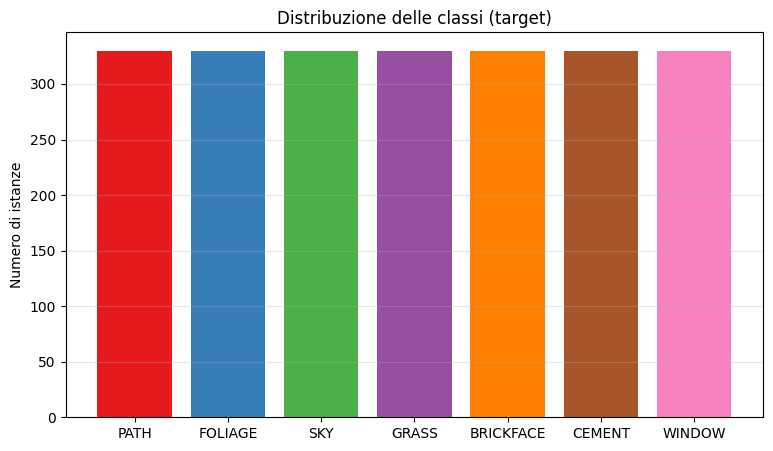

```python
target_counts = data['class'].value_counts()
print('Distribuzione delle classi:')
display(target_counts)

fig, ax = plt.subplots(figsize=(9, 5))
colors7 = ['#e41a1c', '#377eb8', '#4daf4a', '#984ea3', '#ff7f00', '#a65628', '#f781bf']
ax.bar(target_counts.index, target_counts.values, color=colors7)
ax.set_title('Distribuzione delle classi (target)')
ax.set_ylabel('Numero di istanze')
ax.grid(axis='y', alpha=0.3)
plt.show()
```

### 2.2 Verifica della feature costante

Come anticipato, la feature `region-pixel-count` vale costantemente 9. Verifichiamolo e la rimozione è obbligatoria: la sua varianza nulla genererebbe divisione per zero in `StandardScaler` e nella PCA il corrispondente autovalore sarebbe 0.

```python
# Verifica feature costanti
constant_cols = [c for c in data.columns if c != 'class' and data[c].nunique() == 1]
print(f'Feature costanti rilevate: {constant_cols}')
for c in constant_cols:
    print(f'  {c}: valore unico = {data[c].iloc[0]}')

# Rimozione
data = data.drop(columns=constant_cols)
print(f'\nDataset dopo la rimozione: {data.shape} (18 feature utili + class)')
```

```
Feature costanti rilevate: ['region-pixel-count']
  region-pixel-count: valore unico = 9

Dataset dopo la rimozione: (2310, 19) (18 feature utili + class)
```

### 2.3 Distribuzione delle feature per classe

Esaminiamo alcune feature numeriche chiave (intensità media, eccessi di colore, statistiche di edge) per classe. Ci aspettiamo che le feature di colore separino bene le classi naturali (`SKY`, `GRASS`, `FOLIAGE`), mentre le feature di texture e bordi siano più rilevanti per le classi urbane (`BRICKFACE`, `CEMENT`, `WINDOW`).

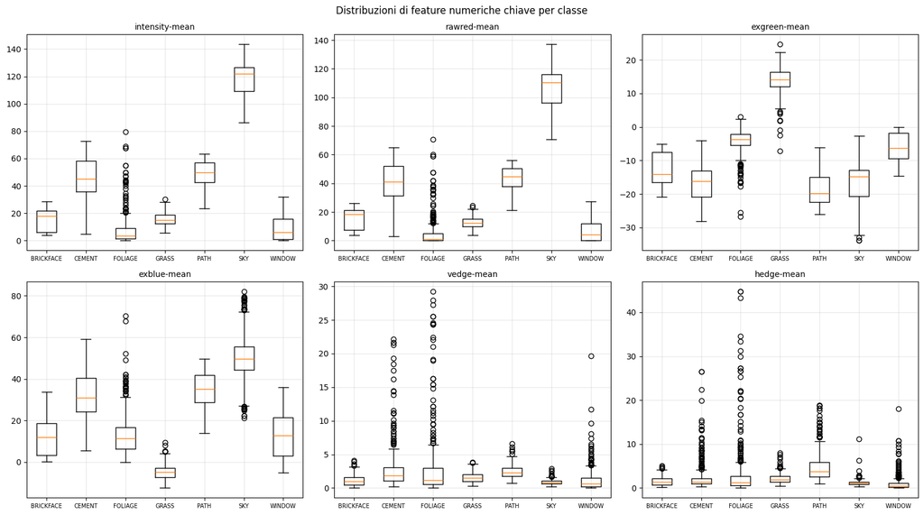

```python
key_features = ['intensity-mean', 'rawred-mean', 'exgreen-mean', 'exblue-mean',
                'vedge-mean', 'hedge-mean']
class_order = sorted(data['class'].unique())

fig, axes = plt.subplots(2, 3, figsize=(16, 9))
for ax, col in zip(axes.flatten(), key_features):
    grouped = [data.loc[data['class']==c, col].values for c in class_order]
    ax.boxplot(grouped, tick_labels=class_order)
    ax.set_title(col, fontsize=10)
    ax.grid(alpha=0.3)
    ax.tick_params(axis='x', labelsize=7)
plt.suptitle('Distribuzioni di feature numeriche chiave per classe', fontsize=12)
plt.tight_layout()
plt.show()
```

I boxplot sono il primo strumento di valutazione visiva della separabilità delle classi. Per ogni feature mostrano la distribuzione (mediana, quartili, outlier) raggruppata per classe.

**Attese per i modelli successivi**: `SKY` e `GRASS` (che si separano nettamente in modo lineare sui boxplot) saranno facili da classificare. `WINDOW`, `CEMENT`, `BRICKFACE`, `FOLIAGE`, `PATH` — che sovrappongono le mediane e differiscono solo negli outlier — saranno più difficili e richiederanno modelli non lineari (kernel SVM, MLP).

### 2.4 Matrice di correlazione

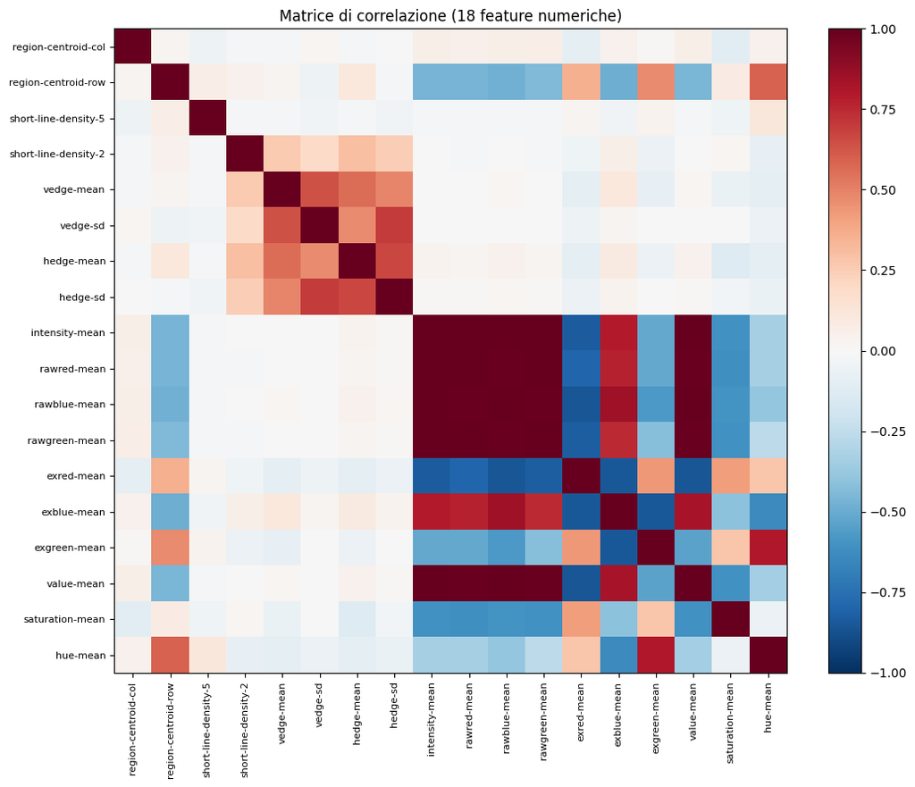

```python
feature_cols = [c for c in data.columns if c != 'class']
corr = data[feature_cols].corr()
fig, ax = plt.subplots(figsize=(11, 9))
im = ax.imshow(corr.values, cmap='RdBu_r', vmin=-1, vmax=1, aspect='auto')
ax.set_xticks(range(len(feature_cols)))
ax.set_yticks(range(len(feature_cols)))
ax.set_xticklabels(feature_cols, rotation=90, fontsize=8)
ax.set_yticklabels(feature_cols, fontsize=8)
ax.set_title('Matrice di correlazione (18 feature numeriche)')
plt.colorbar(im, ax=ax)
plt.tight_layout()
plt.show()
```

Sono evidenti **due blocchi di forte correlazione**:

1. Le feature `intensity-mean`, `rawred-mean`, `rawblue-mean`, `rawgreen-mean` hanno correlazioni $+1$ tra loro. Questo conferma la ridondanza di rappresentare il colore con 4 medie diverse: una sola componente principale è capace di catturare quasi tutta la varianza di luminosità.
2. **Blocco texture/edge**: `vedge-mean`/`vedge-sd` e `hedge-mean`/`hedge-sd` sono correlate tra loro (regioni con molti bordi verticali tendono ad avere anche più bordi orizzontali in scena urbana).
3. **Correlazioni tra feature di colore "raw" ed "excess"**: la formula $\text{exblue} = 2B - (R+G)$ suggerirebbe una correlazione **negativa** tra `exblue-mean` e `rawred-mean`, ma la matrice mostra invece una correlazione **positiva**. Questo perché in Statlog l'effetto "luminosità comune" domina l'effetto matematico della sottrazione. È una conferma che i dati non seguono meccanicamente le formule teoriche, ma sono influenzati dalla loro struttura reale (illuminazione, tipo di scena).

**Implicazione pratica**: la PCA sarà efficace nel ridurre la dimensionalità perché ci sono **gruppi di feature ridondanti** che possono essere riassunti in poche componenti.

### 2.5 Distribuzione individuale delle feature

Dopo aver visto le correlazioni *tra* feature e le distribuzioni *per classe*, completiamo l'analisi esplorativa guardando la **forma della distribuzione di ciascuna feature** indipendentemente dalla classe. Questo serve a:

1. **Identificare distribuzioni asimmetriche**, che possono indicare la presenza di sotto-categorie nei dati;
2. **Individuare visivamente la presenza di outlier** (code lunghe, valori isolati);
3. **Confermare la disparità di scale** che giustifica la standardizzazione (la formula $\tilde{x} = (x-\mu)/\sigma$ ha senso quando le feature hanno scale diverse, come visibile a colpo d'occhio dai range degli assi).

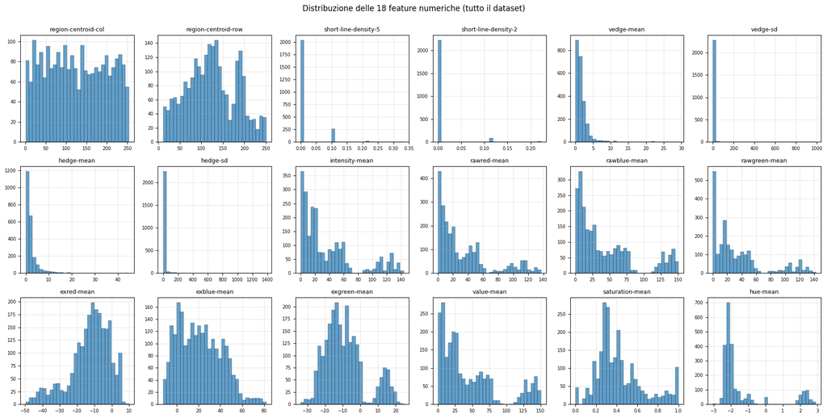

```python
# Griglia 3x6 di istogrammi delle 18 feature
fig, axes = plt.subplots(3, 6, figsize=(18, 9))
for ax, col in zip(axes.flatten(), feature_cols):
    ax.hist(data[col].values, bins=30, color='tab:blue', alpha=0.7, edgecolor='black', linewidth=0.3)
    ax.set_title(col, fontsize=9)
    ax.tick_params(axis='both', labelsize=7)
    ax.grid(alpha=0.3)
plt.suptitle('Distribuzione delle 18 feature numeriche (tutto il dataset)', fontsize=12, y=1.00)
plt.tight_layout()
plt.show()
```

La griglia mostra distribuzioni molto diverse tra loro, che si possono raggruppare in **quattro pattern visivi ricorrenti**.

#### 1. Distribuzioni approssimativamente uniformi (posizione)

**`region-centroid-col`** ha una distribuzione **quasi piatta** su tutto il range $[0, 254]$: le regioni sono estratte uniformemente sulla colonna. **`region-centroid-row`** è invece **leggermente bimodale**, con un grande picco centrale intorno alla riga $100$-$140$ e un secondo picco più piccolo verso $180$-$190$: la maggior parte delle regioni proviene dalla parte alta/centrale delle immagini, con una sotto-popolazione nella parte bassa.

#### 2. Distribuzioni con picco a zero e coda destra estrema (texture)

**Tutte le feature di texture** presentano lo stesso pattern visivo: un **picco altissimo esattamente a zero** e una **coda destra sottilissima**. In particolare:

- **`short-line-density-5` e `short-line-density-2`**: praticamente tutti i $2310$ campioni sono a zero, con solo pochi punti sparsi verso valori positivi;
- **`vedge-mean` e `hedge-mean`**: picco a $0$-$2$, poi decadimento esponenziale con coda che si estende fino a $30$-$45$;
- **`vedge-sd` e `hedge-sd`**: il caso più estremo — quasi tutti i campioni sono in un singolo bin a sinistra, mentre l'asse $x$ si estende fino a $1000$ e $1400$ rispettivamente. Nell'istogramma **la coda è quasi invisibile** perché i pochissimi outlier sono così isolati che matplotlib non riesce a rappresentarli come barre visibili.

Sono queste code invisibili che identificheremo negli outlier di `FOLIAGE` nella PC2 della PCA.

#### 3. Distribuzioni multimodali (colore RGB e luminosità)

**`intensity-mean`, `rawred-mean`, `rawblue-mean`, `rawgreen-mean`, `value-mean`** mostrano tutte lo stesso profilo caratteristico: **un grande picco iniziale nella zona scura** (valori $0$-$20$), un **plateau intermedio** con oscillazioni tra $20$ e $80$, e — in tutte tranne `intensity-mean` — un **picco secondario ben distinto verso valori alti** ($120$-$150$).

Questo profilo bimodale/multimodale rivela la **struttura naturale del dataset**: la stragrande maggioranza delle regioni ha luminosità medio-bassa (superfici scure/urbane), mentre una minoranza forma un blocco separato di regioni molto luminose — sono i **pixel di `SKY`**, che dominano il picco secondario. In `intensity-mean` il picco secondario è più sfumato perché intensity aggrega tutti i canali RGB e il segnale è più smussato.

#### 4. Distribuzioni centrate a media negativa (eccessi di colore) e casi speciali (saturation, hue)

**`exred-mean`** è una distribuzione **quasi gaussiana asimmetrica** centrata intorno a $-15$: quasi nessuna regione di Statlog ha eccesso di rosso, con una piccola coda destra vicino a zero (probabilmente `BRICKFACE`).

**`exgreen-mean`** è **bimodale**: un grande picco intorno a $-10$ per la maggior parte delle classi, e un **piccolo picco isolato a $+15$-$+20$** che rappresenta le sole regioni di `GRASS`. Questa separazione visiva è la miglior anticipazione del perché la PC3 riuscirà a isolare `GRASS`.

**`saturation-mean`** è **multimodale**: picco principale intorno a $0.3$-$0.4$, coda verso valori bassi, e un **picco isolato a $\approx 1.0$** che segnala una sotto-popolazione di regioni completamente sature (probabilmente `GRASS`).

**`hue-mean`** è il caso più visivamente eloquente: **fortemente bimodale**, con un picco enorme intorno a $-2$ (dove sta la maggior parte delle regioni) e un **secondo picco netto isolato a $+2$-$+3$**.

#### Osservazione trasversale: disparità di scale

Guardando i range degli assi $x$:

- `vedge-sd` e `hedge-sd` arrivano a $\sim 1000$–$1400$;
- Le feature RGB e di posizione stanno in $[0, 250]$;
- Gli eccessi di colore stanno tra $-50$ e $+80$;
- `saturation-mean` è in $[0, 1]$;
- `hue-mean` è in $[-3, +3]$;
- `short-line-density-*` è in $[0, 0.35]$.

#### Predizioni per le sezioni successive

Da queste osservazioni visive posso già anticipare:

1. **PCA**: le RGB si aggregheranno in una PC1 di luminosità/colore blu (visibile nel picco secondario delle RGB); la texture nella PC2 (grazie agli outlier di `vedge/hedge`); il picco isolato di `exgreen` e `hue` genererà una PC3 legata al "verde saturo".
2. **MDA**: `SKY` sarà facilmente separato dal resto (secondo picco delle RGB + coda `exblue`); `GRASS` grazie al picco isolato di `exgreen` e `hue`.
3. **Classificatori**: le classi urbane (`CEMENT`, `WINDOW`, `BRICKFACE`) — che si concentrano tutte nel picco scuro delle RGB e non hanno pattern distintivi visibili — saranno le più difficili da distinguere.

## 3. Preparazione dei dati

Prima di applicare le tecniche di machine learning è necessario preparare i dati in modo da poter valutare in maniera **onesta** la qualità dei modelli. Le operazioni sono tre, presentate nelle sotto-sezioni seguenti:

1. **Encoding del target**: trasformiamo le etichette stringa in interi;
2. **Suddivisione train/validation/test**: tre insiemi disgiunti, con motivazione e schema di split;
3. **Standardizzazione delle feature** : rimuove la disparità di scale che comprometterebbe PCA, FDA, SVM.

### 3.1 Encoding del target e separazione delle matrici $\mathbf{X}$ e $\mathbf{y}$

Il target `class` è una stringa (`BRICKFACE`, `SKY`, …) e va trasformato in interi tramite `LabelEncoder` per essere passato agli stimatori di scikit-learn. La trasformazione è puramente nominale: i sette valori 0–6 non hanno ordinamento intrinseco, sono solo identificativi numerici delle classi.

Le 18 feature di Statlog sono invece **tutte numeriche continue** — non c'è bisogno di *one-hot encoding*.

Dopo l'encoding salviamo i dati nella forma standard del machine learning supervisionato: $$ \mathbf{X} \in \mathbb{R}^{N \times n}, \qquad \mathbf{y} \in \{0, 1, 2, 3, 4, 5, 6\}^N $$ dove $N = 2310$ è il numero di istanze e $n = 18$ il numero di feature. La matrice $\mathbf{X}$ ha una istanza per riga e una feature per colonna; il vettore $\mathbf{y}$ contiene la classe codificata di ciascuna istanza.

```python
# Encoding del target
# Creiamo una COPIA del dataset per non perdere i nomi originali delle classi
statlog = data.copy()

# Creazione dell'oggetto LabelEncoder
le = LabelEncoder()

le.fit(statlog['class'])
y = le.transform(statlog['class'].values)

statlog['class'] = y

class_names = le.classes_
print('Mapping classi:')
for index, c_name in enumerate(class_names):
    print(f'  Classe {index}: {c_name}')

# Verifica: ora la colonna 'class' contiene interi
statlog.head()
```

```
Mapping classi:
  Classe 0: BRICKFACE
  Classe 1: CEMENT
  Classe 2: FOLIAGE
  Classe 3: GRASS
  Classe 4: PATH
  Classe 5: SKY
  Classe 6: WINDOW
```

|  | region-centroid-col | region-centroid-row | short-line-density-5 | short-line-density-2 | vedge-mean | vedge-sd | hedge-mean | hedge-sd | intensity-mean | rawred-mean | rawblue-mean | rawgreen-mean | exred-mean | exblue-mean | exgreen-mean | value-mean | saturation-mean | hue-mean | class |
| --- | --- | --- | --- | --- | --- | --- | --- | --- | --- | --- | --- | --- | --- | --- | --- | --- | --- | --- | --- |
| 0 | 218.0 | 178.0 | 0.111111 | 0.0 | 0.833333 | 0.547722 | 1.111109 | 0.544331 | 59.629630 | 52.444443 | 75.222220 | 51.222220 | -21.555555 | 46.77778 | -25.222221 | 75.222220 | 0.318996 | -2.040554 | 4 |
| 1 | 113.0 | 130.0 | 0.000000 | 0.0 | 0.277778 | 0.250924 | 0.333333 | 0.365148 | 0.888889 | 0.000000 | 2.555556 | 0.111111 | -2.666667 | 5.00000 | -2.333333 | 2.555556 | 1.000000 | -2.123254 | 2 |
| 2 | 202.0 | 41.0 | 0.000000 | 0.0 | 0.944448 | 0.772202 | 1.111112 | 1.025597 | 123.037040 | 111.888885 | 139.777790 | 117.444440 | -33.444443 | 50.22222 | -16.777779 | 139.777790 | 0.199347 | -2.299918 | 5 |
| 3 | 32.0 | 173.0 | 0.000000 | 0.0 | 1.722222 | 1.781593 | 9.000000 | 6.749488 | 43.592594 | 39.555557 | 52.888890 | 38.333336 | -12.111111 | 27.88889 | -15.777778 | 52.888890 | 0.266914 | -1.998857 | 4 |
| 4 | 61.0 | 197.0 | 0.000000 | 0.0 | 1.444444 | 1.515353 | 2.611111 | 1.925463 | 49.592594 | 44.222220 | 61.555557 | 43.000000 | -16.111110 | 35.88889 | -19.777779 | 61.555557 | 0.302925 | -2.022274 | 4 |

### 3.2 Suddivisione in training / validation / test set

Suddividere i dati in insiemi disgiunti è necessario per poter valutare i modelli in maniera **onesta**, senza sovrastimare la loro capacità di generalizzazione. Le motivazioni sono tre:

1. **Evitare l'illusione di accuratezza** (*overfitting*): valutare un modello sui dati su cui è stato addestrato dà sempre performance artificiosamente ottimistiche, perché il modello ha già "visto" gli esempi specifici e può averli memorizzati.
2. **Stimare la capacità di generalizzazione**: per sapere come il modello si comporta su dati mai visti prima, dobbiamo riservare una parte del dataset esclusivamente alla valutazione finale.
3. **Scegliere gli iper-parametri senza "barare" sul test set**: molti modelli (es. SVM) hanno *iper-parametri* che dobbiamo scegliere prima dell'addestramento — ad esempio il valore di $C$ nell'SVM.

   Per evitare questo, si riserva un **terzo insieme separato — il *validation set* —** che usiamo per confrontare configurazioni e scegliere gli iper-parametri. Il test set viene toccato **una sola volta**, alla fine, per la valutazione finale del modello scelto.

Adottiamo la **suddivisione a 3 vie 50/15/35**, che offre un buon compromesso: training set ampio per far apprendere bene i modelli, validation compatto per la grid search, test set grande per una valutazione statisticamente affidabile.

| Insieme | Percentuale | Numero istanze | Per classe | Uso |
| --- | --- | --- | --- | --- |
| **Training** | 50% | $\sim$ 1155 | $\sim$ 165 | *fit* di tutti i modelli e degli stimatori di preprocessing |
| **Validation** | 15% | $\sim$ 346 | $\sim$ 50 | selezione degli iper-parametri (grid search SVM) |
| **Test** | 35% | $\sim$ 809 | $\sim$ 115 | **intoccato** fino alla valutazione finale |

Sklearn non offre direttamente un `train_val_test_split`, ma si ottiene chiamando `train_test_split` **due volte**:

1. Prima divisione: separiamo il **test set** (35%) dal resto (65%)
2. Seconda divisione: dal restante 65%, ricaviamo il **training** (50% del totale = 76.9% del restante) e il **validation** (15% del totale = 23.1% del restante)

Entrambe le divisioni sono **stratificate**: `stratify=y` preserva la proporzione delle classi in ciascun sottoinsieme (per Statlog, che ha 330 esempi per classe, questo assicura ~165/50/115 istanze per classe rispettivamente in train/val/test).

```python
# Suddivisione dei dati in Training / Validation / Test
# Split a 3 vie: 50% train / 15% validation / 35% test.

# Seed per la riproducibilità delle operazioni casuali
random_state = 42

# Estrazione della matrice delle feature X (2310 x 18) dal DataFrame
X = data.drop(columns=['class']).values

# Percentuali di split (in percentuali sul totale)
test_p = 0.35                  # 35% del totale --> TEST
val_p  = 0.15 / (1 - test_p)   # 15% del totale = 23.08% del rimanente --> VALIDATION
                               # Rimane il 50% del totale --> TRAINING

# Separo il TEST set (35%) dal resto (65% train+val)
X_temp, X_test, y_temp, y_test = train_test_split(
    X, y,
    test_size=test_p,
    random_state=random_state,
    stratify=y,
    shuffle=True
)

# Dal restante 65% (train+val) separiamo TRAINING e VALIDATION
# val_p = 0.15 / 0.65 ≈ 0.2308 --> 23.08% del temp diventa validation (=15% del totale)
X_train, X_val, y_train, y_val = train_test_split(
    X_temp, y_temp,
    test_size=val_p,
    random_state=random_state,
    stratify=y_temp,
    shuffle=True
)

# Verifica dimensioni e distribuzione classi
print(f'Train:      {X_train.shape}  ({X_train.shape[0]/X.shape[0]*100:.1f}% del totale)')
print(f'Validation: {X_val.shape}    ({X_val.shape[0]/X.shape[0]*100:.1f}% del totale)')
print(f'Test:       {X_test.shape}   ({X_test.shape[0]/X.shape[0]*100:.1f}% del totale)')
print()
print(f'Distribuzione classi nel training:   {np.bincount(y_train)}')
print(f'Distribuzione classi nel validation: {np.bincount(y_val)}')
print(f'Distribuzione classi nel test:       {np.bincount(y_test)}')
```

```
Train:      (1154, 18)  (50.0% del totale)
Validation: (347, 18)    (15.0% del totale)
Test:       (809, 18)   (35.0% del totale)

Distribuzione classi nel training:   [165 165 165 165 164 165 165]
Distribuzione classi nel validation: [50 50 49 49 50 50 49]
Distribuzione classi nel test:       [115 115 116 116 116 115 116]
```

### 3.3 Standardizzazione delle feature

Stampiamo le **statistiche descrittive** delle 18 feature.

```python
# Statistiche descrittive delle 19 feature
display(data.describe().T)
```

|  | count | mean | std | min | 25% | 50% | 75% | max |
| --- | --- | --- | --- | --- | --- | --- | --- | --- |
| region-centroid-col | 2310.0 | 124.913853 | 72.956532 | 1.000000e+00 | 62.000000 | 121.000000 | 189.000000 | 254.000000 |
| region-centroid-row | 2310.0 | 123.417316 | 57.483851 | 1.100000e+01 | 81.000000 | 122.000000 | 172.000000 | 251.000000 |
| short-line-density-5 | 2310.0 | 0.014334 | 0.040154 | 0.000000e+00 | 0.000000 | 0.000000 | 0.000000 | 0.333333 |
| short-line-density-2 | 2310.0 | 0.004714 | 0.024234 | 0.000000e+00 | 0.000000 | 0.000000 | 0.000000 | 0.222222 |
| vedge-mean | 2310.0 | 1.893939 | 2.698908 | 0.000000e+00 | 0.722222 | 1.222224 | 2.166667 | 29.222221 |
| vedge-sd | 2310.0 | 5.709320 | 44.846457 | 0.000000e+00 | 0.355555 | 0.833333 | 1.806367 | 991.718400 |
| hedge-mean | 2310.0 | 2.424723 | 3.610084 | 0.000000e+00 | 0.777780 | 1.444444 | 2.555556 | 44.722225 |
| hedge-sd | 2310.0 | 8.243692 | 58.811517 | -1.589457e-08 | 0.421637 | 0.962963 | 2.183269 | 1386.329200 |
| intensity-mean | 2310.0 | 37.051595 | 38.176410 | 0.000000e+00 | 7.296296 | 21.592592 | 53.212964 | 143.444440 |
| rawred-mean | 2310.0 | 32.821308 | 35.036774 | 0.000000e+00 | 7.000000 | 19.555555 | 47.333332 | 137.111110 |
| rawblue-mean | 2310.0 | 44.187879 | 43.527461 | 0.000000e+00 | 9.555555 | 27.666667 | 64.888890 | 150.888890 |
| rawgreen-mean | 2310.0 | 34.145599 | 36.364773 | 0.000000e+00 | 6.027778 | 20.333334 | 46.500001 | 142.555560 |
| exred-mean | 2310.0 | -12.690861 | 11.583562 | -4.966667e+01 | -18.555555 | -10.888889 | -4.222222 | 9.888889 |
| exblue-mean | 2310.0 | 21.408850 | 19.571819 | -1.244444e+01 | 4.138889 | 19.666666 | 35.777780 | 82.000000 |
| exgreen-mean | 2310.0 | -8.717989 | 11.551628 | -3.388889e+01 | -16.777779 | -10.888889 | -3.222222 | 24.666666 |
| value-mean | 2310.0 | 45.137470 | 42.921764 | 0.000000e+00 | 11.555555 | 28.666666 | 64.888890 | 150.888890 |
| saturation-mean | 2310.0 | 0.426893 | 0.228309 | 0.000000e+00 | 0.284235 | 0.374803 | 0.540123 | 1.000000 |
| hue-mean | 2310.0 | -1.362897 | 1.545335 | -3.044175e+00 | -2.188057 | -2.051200 | -1.562308 | 2.912480 |

Le statistiche descrittive hanno scale molto diverse tra le feature: le coordinate del centroide (`region-centroid-col/row`) variano fra 0 e 254, le feature di colore (`rawred/blue/green-mean`) tra 0 e ~140, mentre `hue-mean` è in $[-3, +3]$ e `saturation-mean` in $[0, 1]$. E' quindi obbligatoria la standardizzazione prima di PCA, FDA e SVM.

Per ricondurre tutte le feature a un confine confrontabile applichiamo `StandardScaler`, che trasforma ciascuna feature $x_i$ in

$$ \tilde{x}_i = \frac{x_i - \mu_i}{\sigma_i} $$

dove $\mu_i$ e $\sigma_i$ sono la media e la deviazione standard della feature $i$ **calcolate sul solo training set**. Lo stesso scaler viene poi usato per trasformare validation e test set.

```python
# Standardizzazione delle feature
scaler = StandardScaler()

# Sul training: calcola mu, sigma e trasforma
X_train_sc = scaler.fit_transform(X_train)

# Su validation e test: applica la STESSA trasformazione (mu, sigma del training)
X_val_sc   = scaler.transform(X_val)
X_test_sc  = scaler.transform(X_test)

# Verifica: dopo lo scaling, media ~0 e std ~1 sul training
# Stampo solo le prime 5 feature per leggibilità (le altre 13 seguono lo stesso pattern)
print('Dimensioni dopo lo scaling:')
print(f'  X_train_sc: {X_train_sc.shape}')
print(f'  X_val_sc:   {X_val_sc.shape}')
print(f'  X_test_sc:  {X_test_sc.shape}')
print()
print('Media e std delle prime 5 feature sul training (devono essere ~0 e ~1):')
print('  Media:', np.round(X_train_sc.mean(axis=0)[:5], 4))
print('  Std:  ', np.round(X_train_sc.std(axis=0)[:5], 4))
```

```
Dimensioni dopo lo scaling:
  X_train_sc: (1154, 18)
  X_val_sc:   (347, 18)
  X_test_sc:  (809, 18)

Media e std delle prime 5 feature sul training (devono essere ~0 e ~1):
  Media: [ 0. -0.  0.  0. -0.]
  Std:   [1. 1. 1. 1. 1.]
```

**Osservazione.** Dopo `StandardScaler` le prime 5 feature hanno media $\approx 0$ e deviazione standard $\approx 1$, come atteso. Sul validation e sul test le statistiche non saranno esattamente 0 e 1 perché abbiamo trasformato con $\mu$ e $\sigma$ calcolati sul training, non sui rispettivi insiemi.

## 4. Principal Component Analysis (PCA)

### 4.1 Descrizione del metodo

La **Principal Component Analysis (PCA)** è una tecnica di **riduzione della dimensionalità non supervisionata**. Trasforma un insieme di dati tra loro correlati in un nuovo insieme di vettori **non correlati** e ortogonali tra loro, dette *componenti principali*, mantenendo la maggior parte della varianza (informazione) originale. Si basa sulla decomposizione SVD della matrice di covarianza centrata.

Data la matrice dei dati $X = [\boldsymbol{x}_1, \dots, \boldsymbol{x}_N] \in \mathbb{R}^{n \times N}$ (una colonna per istanza), eseguiamo il **centraggio** sottraendo la media di ogni colonna a ciascun vettore-istanza, ottenendo la matrice centrata $$ \tilde{X} = X - \bar{\boldsymbol{\mu}} $$ dove $\bar{\boldsymbol{\mu}}$ è il vettore delle medie. Si definiscono:

- la **matrice di dispersione (scatter matrix)**: $$ S = \tilde{X}^\top \tilde{X} $$
- la **sample variance-covariance matrix** (versione *unbiased*): $$ \Sigma = \frac{1}{N-1} \tilde{X}^\top \tilde{X} $$

Entrambe sono matrici **simmetriche** e **semidefinite positive**. Le direzioni principali dei dati sono gli **autovettori** di $S$ (equivalentemente, di $\Sigma$).

#### Calcolo delle componenti principali via SVD

Possiamo calcolare le componenti principali tramite la decomposizione SVD di $\tilde{X}$: $$ \tilde{X} = U D V^\top, \qquad \tilde{X} \tilde{X}^\top = U D^2 U^\top $$ dove $D$ è la matrice **diagonale** dei valori singolari $\sigma_1 \ge \sigma_2 \ge \dots \ge 0$.

I vettori singolari sinistri di $\tilde{X}$ (le colonne di $U$) sono le **componenti principali**, ordinate per dimensione decrescente dei valori singolari. A ogni componente è associato un autovalore $\lambda_i = \sigma_i^2$, che rappresenta la **varianza spiegata** da quella direzione.

#### Criterio PVE (Proportion of Variance Explained)

Per decidere quante componenti tenere, si fissa una percentuale soglia (es. 85%) e si sceglie $k$ tale che: $$ \eta_k = \frac{\sum_{i=1}^{k} \sigma_i^2}{\sum_{i=1}^{n} \sigma_i^2} \ge 0{.}85 $$

#### Formulazione come minimizzazione dell'errore di rappresentazione

Sia $V \subseteq \mathbb{R}^d$ uno spazio lineare di dimensione $d$ e $W \subseteq V$ un sottospazio di dimensione $k < d$. Esiste una base ortonormale $\{\boldsymbol{e}_1, \dots, \boldsymbol{e}_k\}$ di $W$ tale che ogni vettore di $W$ si scrive come $\sum_{j=1}^k a_j \boldsymbol{e}_j$.

L'errore di rappresentazione del dato $\boldsymbol{x}_i$ tramite la sua proiezione su $W$ è $\|\boldsymbol{x}_i - \sum_j a_{ij}\boldsymbol{e}_j\|$. Sommando su tutti gli $N$ dati, otteniamo la **funzione obiettivo da minimizzare**: $$ J(\boldsymbol{e}_1, \dots, \boldsymbol{e}_k,\, a_{11}, \dots, a_{Nk}) = \sum_{i=1}^{N} \left\| \boldsymbol{x}_i - \sum_{j=1}^{k} a_{ij}\, \boldsymbol{e}_j \right\|^2 $$ soggetto ai vincoli $\|\boldsymbol{e}_j\|^2 = 1$ e $\boldsymbol{e}_i^\top \boldsymbol{e}_j = 0$ per $i \ne j$ (ortonormalità).

Dopo l'uso dei moltiplicatori di Lagrange per imporre i vincoli e dopo l'eliminazione dei termini costanti tramite derivate parziali, la soluzione del problema di ottimizzazione si riduce all'**equazione agli autovalori della scatter matrix** $S$: $$ S \boldsymbol{e}_j = \lambda_j \boldsymbol{e}_j $$

**Conclusione**: per minimizzare l'errore di rappresentazione si prendono come basi del sottospazio $W$ i $k$ autovettori di $S$ corrispondenti ai $k$ **autovalori più grandi**. Maggiore è $\lambda_j$, maggiore è la varianza dei dati lungo la direzione $\boldsymbol{e}_j$.

#### PCA come approssimazione dei dati: il teorema delle proiezioni

Una volta scelti $k$ autovettori ortonormali $\boldsymbol{e}_1, \dots, \boldsymbol{e}_k$ di $S$, il sottospazio principale $W = \text{span}\{\boldsymbol{e}_1, \dots, \boldsymbol{e}_k\}$ è un sottospazio di $\mathbb{R}^n$ di dimensione $k$. Per il **Teorema delle Proiezioni** in spazi con prodotto scalare, la **proiezione ortogonale** di un vettore $\boldsymbol{x} \in \mathbb{R}^n$ su $W$ è data da: $$ P_W \boldsymbol{x} = \sum_{i=1}^{k} \langle \boldsymbol{x}, \boldsymbol{e}_i \rangle\, \boldsymbol{e}_i $$ dove $\langle \cdot, \cdot \rangle$ è il prodotto scalare standard di $\mathbb{R}^n$. Per le proprietà del prodotto scalare, $$ \langle \boldsymbol{x}, \boldsymbol{e}_i \rangle = \boldsymbol{e}_i^\top \boldsymbol{x} $$ e quindi la formula diventa, esplicitando le coordinate: $$ \boldsymbol{x} \;\approx\; P_W \boldsymbol{x} = \sum_{i=1}^{k} (\boldsymbol{e}_i^\top \boldsymbol{x})\, \boldsymbol{e}_i $$ Gli scalari $\boldsymbol{e}_i^\top \boldsymbol{x}$ sono le **coordinate** del dato $\boldsymbol{x}$ nella nuova base ortonormale.

**Due proprietà fondamentali** della proiezione che ci interessano:

1. $P_W \boldsymbol{x}$ appartiene a $W$ — è dentro il sottospazio principale, quindi è esprimibile con sole $k$ coordinate invece delle $n$ originali (compressione).
2. L'errore $\boldsymbol{x} - P_W \boldsymbol{x}$ è **ortogonale a tutto $W$**. Conseguenza diretta: $P_W \boldsymbol{x}$ è il **vettore di $W$ più vicino a $\boldsymbol{x}$** in distanza euclidea.

Cioè: $$ P_W \boldsymbol{x} = \arg\min_{\boldsymbol{w} \in W} \| \boldsymbol{x} - \boldsymbol{w} \| $$ Questa è la **garanzia di ottimalità** della PCA: tra tutte le possibili rappresentazioni di $\boldsymbol{x}$ tramite un vettore di $W$, quella che usiamo (la proiezione ortogonale) è esattamente quella con errore minimo.

Sommando sull'intero dataset, otteniamo la giustificazione del **risultato di minimizzazione** che avevamo derivato: il sottospazio $W$ generato dai primi $k$ autovettori di $S$ è il sottospazio $k$-dimensionale che minimizza $\sum_{i=1}^N \| \boldsymbol{x}_i - P_W \boldsymbol{x}_i \|^2$, che è esattamente la nostra funzione obiettivo $J$.

#### Limite della PCA per la classificazione

La PCA trova la rappresentazione più accurata dei dati in uno spazio di dimensione inferiore. **Tuttavia, le direzioni di massima varianza non coincidono necessariamente con le direzioni più discriminanti** rispetto a una variabile di classe: per la classificazione vera e propria servono tecniche supervisionate come FDA/MDA.

### 4.2 PCA su dati standardizzati vs non standardizzati

Le 18 feature di Statlog hanno scale molto diverse. Senza standardizzazione la PCA assegna quasi tutta la varianza alle componenti correlate con le feature di scala maggiore. Lo confermiamo eseguendo la PCA sui dati grezzi e su quelli standardizzati.

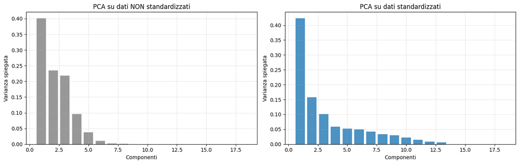

```
 PC    Senza scaling    Cum. no-std     Con scaling    Cum. std
------------------------------------------------------------------
  1          40.09 %        40.09 %         42.30 %     42.30 %
  2          23.53 %        63.62 %         15.75 %     58.05 %
  3          21.82 %        85.44 %         10.08 %     68.13 %
  4           9.53 %        94.98 %          5.88 %     74.01 %
  5           3.73 %        98.71 %          5.21 %     79.23 %
  6           0.99 %        99.70 %          4.99 %     84.22 %
  7           0.25 %        99.95 %          4.23 %     88.45 %
  8           0.03 %        99.98 %          3.39 %     91.84 %
  9           0.01 %        99.99 %          3.02 %     94.86 %
 10           0.01 %       100.00 %          2.21 %     97.07 %
```

```python
# PCA su dati NON standardizzati vs standardizzati
pca_nostd = PCA()
pca_nostd.fit(X_train)      # NON standardizzati
pca_tmp = PCA()
pca_tmp.fit(X_train_sc)     # standardizzati

# Bar chart varianza spiegata per ciascuna componente
fig, axes = plt.subplots(1, 2, figsize=(14, 4.5))
axes[0].bar(range(1, len(pca_nostd.explained_variance_ratio_)+1),
            pca_nostd.explained_variance_ratio_, color='tab:gray', alpha=0.8)
axes[0].set_title('PCA su dati NON standardizzati')
axes[0].set_xlabel('Componenti'); axes[0].set_ylabel('Varianza spiegata')
axes[0].grid(alpha=0.3)

axes[1].bar(range(1, len(pca_tmp.explained_variance_ratio_)+1),
            pca_tmp.explained_variance_ratio_, color='tab:blue', alpha=0.8)
axes[1].set_title('PCA su dati standardizzati')
axes[1].set_xlabel('Componenti'); axes[1].set_ylabel('Varianza spiegata')
axes[1].grid(alpha=0.3)
plt.tight_layout()
plt.show()

# Tabella di confronto delle prime 10 componenti
print()
print(f'{"PC":>3s}  {"Senza scaling":>15s}  {"Cum. no-std":>13s}   {"Con scaling":>13s}  {"Cum. std":>10s}')
print('-' * 66)
cum_nostd = 0.0
cum_std   = 0.0
for k in range(10):
    var_nostd = pca_nostd.explained_variance_ratio_[k] * 100
    var_std   = pca_tmp.explained_variance_ratio_[k] * 100
    cum_nostd += var_nostd
    cum_std   += var_std
    print(f'{k+1:>3d}  {var_nostd:>13.2f} %  {cum_nostd:>11.2f} %   {var_std:>11.2f} %  {cum_std:>8.2f} %')
```

Guardando la tabella si nota **subito** una differenza importante nel modo in cui la varianza è distribuita tra le componenti nei due casi.

#### Osservazione chiave: senza scaling la varianza collassa in pochissime componenti

**Senza standardizzazione:**

- Le prime **3 componenti** catturano già l'**85% della varianza totale**.
- Le prime **4 componenti** raggiungono il **95%**.
- Dopo la 5$^\text{a}$ componente si è già oltre il **98%**, e dalla 8$^\text{a}$ in poi la varianza aggiunta è **praticamente zero** ($< 0.05\%$).

**Con standardizzazione:**

- Le prime **3 componenti** catturano solo il **68%** della varianza.
- Per arrivare al **95%** servono **10 componenti**.
- Il decadimento è molto più graduale.

A prima vista lo scenario senza standardizzazione sembra **preferibile**: la PCA sembra "più efficiente", perché comprime quasi tutta l'informazione in appena 4 dimensioni. In realtà è un **artefatto della scala di misura**, non un'informazione strutturale del dataset.

#### Perché la varianza collassa in poche PC senza standardizzazione

Il "guadagno" apparente della PCA senza scaling — coprire il $95\%$ della varianza in appena 4 componenti — **non è un guadagno**: è la conferma che senza scaling la PCA è dominata da un piccolo numero di feature ad alto range. La PCA con scaling ha decadimento più graduale perché sta **effettivamente distribuendo la varianza** tra tutte le direzioni informative del dataset, non solo quelle a scala grande. È esattamente ciò che vogliamo per fare interpretazione semantica e per preparare dati compatibili con MDA, SVM e MLP.

Per tutte queste ragioni, **dalla 4.3 in poi useremo sempre `X_train_sc`, `X_val_sc`, `X_test_sc`** (i dati standardizzati). Il confronto std vs no-std di questa sezione serve a mostrare esplicitamente che *l'apparente efficienza* della PCA senza scaling è solo un artefatto della disparità di scale delle feature originali.

### 4.3 PCA sui dati standardizzati: scree plot e varianza cumulata

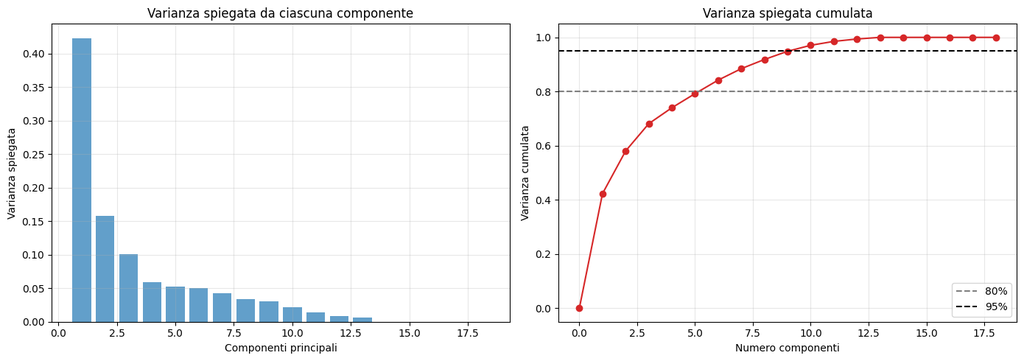

```
Numero di componenti principali necessarie per spiegare le soglie di varianza:
```

|  | Soglia varianza | Componenti necessarie | Frazione delle PC totali |
| --- | --- | --- | --- |
| 0 | 50% | 2 | 2/18 |
| 1 | 70% | 4 | 4/18 |
| 2 | 80% | 6 | 6/18 |
| 3 | 85% | 7 | 7/18 |
| 4 | 90% | 8 | 8/18 |
| 5 | 95% | 10 | 10/18 |
| 6 | 99% | 12 | 12/18 |

```python
pca_full = PCA()
pca_full.fit(X_train_sc)

expld = pca_full.explained_variance_ratio_
expld_cum = np.insert(np.cumsum(expld), 0, 0)

fig, axes = plt.subplots(1, 2, figsize=(14, 5))
axes[0].bar(range(1, len(expld)+1), expld, color='tab:blue', alpha=0.7)
axes[0].set_title('Varianza spiegata da ciascuna componente')
axes[0].set_xlabel('Componenti principali'); axes[0].set_ylabel('Varianza spiegata')
axes[0].grid(alpha=0.3)

axes[1].plot(expld_cum, marker='o', color='tab:red')
axes[1].axhline(0.8, ls='--', color='gray', label='80%')
axes[1].axhline(0.95, ls='--', color='black', label='95%')
axes[1].set_title('Varianza spiegata cumulata')
axes[1].set_xlabel('Numero componenti'); axes[1].set_ylabel('Varianza cumulata')
axes[1].legend(); axes[1].grid(alpha=0.3)
plt.tight_layout()
plt.show()

# Tabella riepilogativa: per ciascuna soglia di varianza, quante componenti servono?
soglie = [0.50, 0.70, 0.80, 0.85, 0.90, 0.95, 0.99]
df_variance = pd.DataFrame([
    {
        'Soglia varianza': f'{s*100:.0f}%',
        'Componenti necessarie': int(np.argmax(expld_cum >= s)),
        'Frazione delle PC totali': f'{int(np.argmax(expld_cum >= s))}/{len(expld)}'
    }
    for s in soglie
])
print('Numero di componenti principali necessarie per spiegare le soglie di varianza:')
display(df_variance)

# Conservo le variabili n80 e n95 perche' vengono usate in celle successive (errore di ricostruzione)
n80 = int(np.argmax(expld_cum >= 0.80))
n95 = int(np.argmax(expld_cum >= 0.95))
```

#### Il salto marcato tra PC1 e PC2 e il "vero" gomito

Guardando il bar plot a sinistra si nota subito che **il decremento più netto è tra PC1 e PC2**: la varianza spiegata passa da $\sim 42\%$ a $\sim 16\%$.

Questo salto **non è un gomito**: è invece un indice della **presenza di una direzione dominante** nel dataset: PC1, come vedremo nei loading, corrisponde alla direzione di luminosità/colore blu e cattura da sola più del doppio della varianza di qualsiasi altra direzione.

Il gomito propriamente detto — cioè il punto dopo cui la curva si appiattisce e le componenti aggiuntive contribuiscono in maniera trascurabile — **non è a PC2** perché PC2, PC3, PC4 e PC5 contribuiscono ancora sostanzialmente ($16\%, 10\%, 6\%, 5\%$ rispettivamente).

Il gomito reale su questa curva si trova indicativamente **tra PC5 e PC7**, dove il decadimento diventa graduale e ciascuna componente successiva aggiunge $\sim 3$–$4\%$. Da lì in poi la curva è quasi orizzontale, con componenti che aggiungono meno dell'$1\%$ dopo PC12.

#### Scelta operativa del numero di componenti

Le linee tratteggiate nel plot cumulato identificano due soglie standard:

- **80% di varianza** $\Rightarrow k = 6$ componenti;
- **95% di varianza** $\Rightarrow k = 10$ componenti.

**Per la proiezione 2D di 4.5 (PC1 + PC2)** avremo circa il $58\%$ della varianza — sufficiente a distinguere le classi con struttura più marcata (`SKY`) ma insufficiente per il blocco urbano. **Per la 3D con PC3** saliremo al $\sim 68\%$, guadagnando l'informazione necessaria a isolare anche `GRASS`. Le classi urbane (`CEMENT`, `WINDOW`, `BRICKFACE`) resteranno confuse anche in 3D perché la loro separazione richiede molte più direzioni.

### 4.4 Interpretazione dei *loadings*

I **loadings** sono le componenti dei vettori $\boldsymbol{v}_1, \boldsymbol{v}_2, \boldsymbol{v}_3$ e rappresentano il **peso** di ciascuna feature originale sulle prime tre componenti principali. Un loading di valore assoluto elevato indica che la feature contribuisce molto a quella componente; un loading vicino a zero indica che la feature contribuisce poco.

**Perché vogliamo interpretare le PC in termini di feature originali**: le PC sono direzioni astratte definite matematicamente, ma per usarle nella tesina vogliamo dare loro un **significato semantico** — es. "PC1 = luminosità", "PC2 = texture". Il modo di farlo è guardare quali feature originali hanno i loading maggiori su ciascuna PC.

Costruiamo il bar plot per **tre** componenti principali (PC1, PC2, PC3).

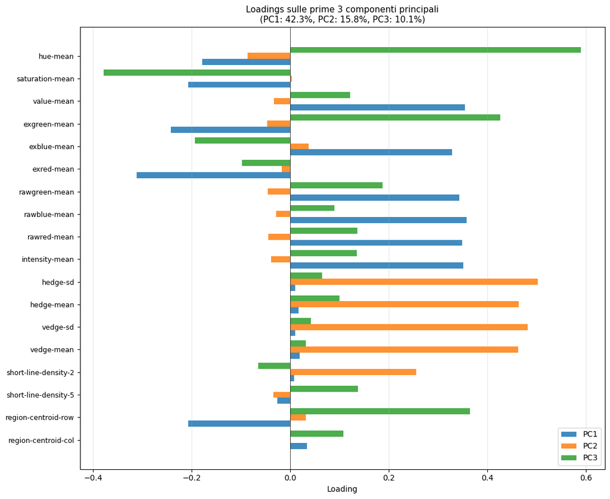

```python
# Fit della PCA: uso 3 componenti
pca = PCA(n_components=3)
pca.fit(X_train_sc)
loadings = pca.components_.T  # shape (n_features, 3)

# Salvo i nomi delle feature (servono per i grafici dei loadings PCA)
feature_names = data.drop(columns=['class']).columns.tolist()

# Plot dei loadings: 3 barre per ciascuna feature (PC1, PC2, PC3)
fig, ax = plt.subplots(figsize=(11, 9))
y_pos = np.arange(len(feature_names))
bar_width = 0.27
ax.barh(y_pos - bar_width, loadings[:, 0], bar_width, label='PC1', color='tab:blue', alpha=0.85)
ax.barh(y_pos,             loadings[:, 1], bar_width, label='PC2', color='tab:orange', alpha=0.85)
ax.barh(y_pos + bar_width, loadings[:, 2], bar_width, label='PC3', color='tab:green', alpha=0.85)
ax.set_yticks(y_pos)
ax.set_yticklabels(feature_names, fontsize=9)
ax.axvline(0, color='black', lw=0.5)
ax.set_xlabel('Loading')
ax.set_title('Loadings sulle prime 3 componenti principali\n'
             f'(PC1: {pca.explained_variance_ratio_[0]*100:.1f}%, '
             f'PC2: {pca.explained_variance_ratio_[1]*100:.1f}%, '
             f'PC3: {pca.explained_variance_ratio_[2]*100:.1f}%)',
             fontsize=11)
ax.legend(loc='lower right')
ax.grid(axis='x', alpha=0.3)
plt.tight_layout()
plt.show()
```

#### PC1 — Luminosità e colore blu

Dominata da 6 feature con **loading positivi $\sim +0.35$**: `intensity-mean`, `value-mean` e i 4 canali RGB (con `exblue-mean`). Contributi negativi da `exred-mean`, `exgreen-mean`, `saturation-mean`, `region-centroid-row` e `hue-mean`.

**Interpretazione:** pixel luminosi + blu + non saturi + nella parte alta dell'immagine → è la descrizione del **cielo**.

#### PC2 — Texture / contrasto dei bordi

Dominata dalle 4 feature di texture (`vedge-mean`, `vedge-sd`, `hedge-mean`, `hedge-sd`) con loading $\sim +0.45$, più `short-line-density-2` con contributo moderato. **Tutte le altre feature hanno loading vicini a zero**: PC2 è quindi *quasi interamente* la dimensione di edge/texture, ortogonale a PC1 (colore).

**Interpretazione:** regioni con **forti gradienti di intensità** — i pixel con outlier di texture visti in §2.5, tipicamente `FOLIAGE`.

#### PC3 — Verde saturo

**Interpretazione:** dimensione cromatica del *"verde saturo"*, ortogonale sia a PC1 sia a PC2 — è la direzione che isola `GRASS` dal resto.

| PC | Significato | Classe che separa |
| --- | --- | --- |
| PC1 | Luminosità + blu | `SKY` |
| PC2 | Texture / contrasto | `FOLIAGE` (outlier) |
| PC3 | Verde saturo | `GRASS` |

La PCA, pur essendo **non supervisionata**, ha ricostruito il vocabolario semantico del problema: colore, texture, verde saturo — le 3 dimensioni ci si aspetta siano rilevanti per distinguere materiali outdoor. Nel seguito useremo queste interpretazioni per leggere lo score plot 2D/3D e il biplot.

### 4.5 Proiezione 2D sulle prime due componenti principali (score plot)

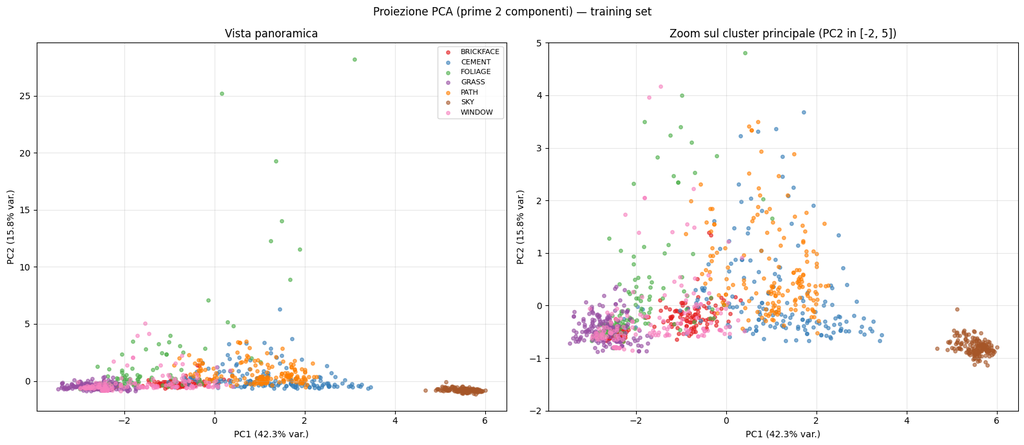

```python
pca2 = PCA(n_components=2)
pca2.fit(X_train_sc)

Z_train_pca = pca2.transform(X_train_sc)
Z_test_pca = pca2.transform(X_test_sc)

# Doppio plot: PANORAMICA (con outlier) e ZOOM sul cluster principale
fig, axes = plt.subplots(1, 2, figsize=(16, 7))

for ax, title, ylim in [
    (axes[0], 'Vista panoramica', None),
    (axes[1], 'Zoom sul cluster principale (PC2 in [-2, 5])', (-2, 5))
]:
    for k, name in enumerate(class_names):
        mask = y_train == k
        ax.scatter(Z_train_pca[mask, 0], Z_train_pca[mask, 1],
                   s=15, alpha=0.6, label=name, color=colors7[k])
    ax.set_xlabel(f'PC1 ({pca2.explained_variance_ratio_[0]*100:.1f}% var.)')
    ax.set_ylabel(f'PC2 ({pca2.explained_variance_ratio_[1]*100:.1f}% var.)')
    ax.set_title(title)
    ax.grid(alpha=0.3)
    if ylim is not None:
        ax.set_ylim(ylim)

axes[0].legend(fontsize=8, loc='upper right')
plt.suptitle('Proiezione PCA (prime 2 componenti) — training set', fontsize=12)
plt.tight_layout()
plt.show()
```

Le prime 2 componenti catturano insieme il **$\sim 58\%$ della varianza** (PC1 $\approx 42.3\%$, PC2 $\approx 16\%$). Usando l'interpretazione dei loading (**PC1 $\approx$ luminosità/blu, PC2 $\approx$ texture**), possiamo leggere direttamente la posizione di ogni classe.

#### Vista panoramica (immagine sinistra)

- **`SKY`** (marrone): completamente isolato a PC1 molto alta → pixel luminosi, blu, non saturi. Cluster separato da tutti gli altri con un *gap* netto: sarà facile classificarla.
- **`FOLIAGE`** (verde): outlier estremi verso PC2 alta → sono le regioni di vegetazione con texture molto marcata (rami/foglie frastagliate) già anticipate dagli outlier di `vedge/hedge`.
- **Blocco urbano sovrapposto** al centro-sinistra: `GRASS`, `WINDOW`, `BRICKFACE` a PC1 negativa; `CEMENT` e `PATH` al centro. Le sole 2 prime PC non bastano a distinguerli: serviranno **kernel non lineari** (RBF) o **MLP** per superare la sovrapposizione visibile.

### Proiezione PCA 3D

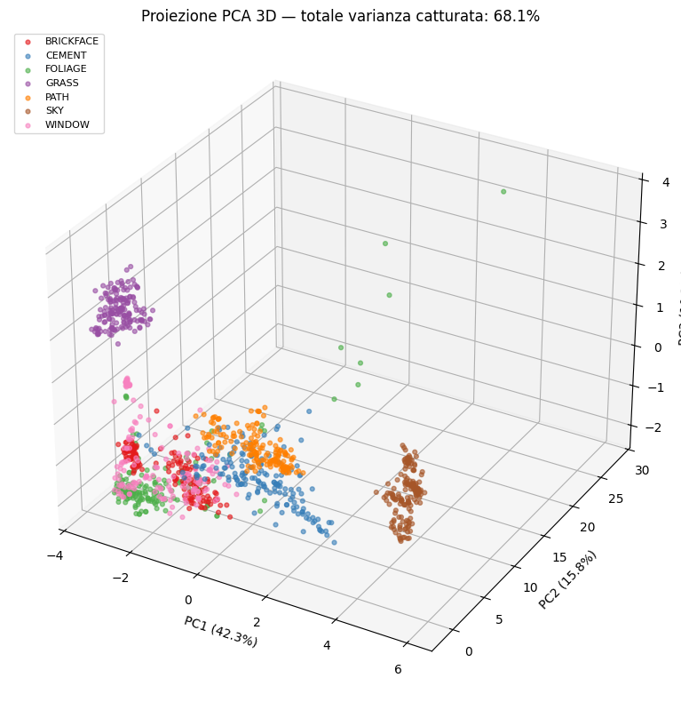

```python
# Proiezione PCA 3D
# Riusiamo l'oggetto 'pca' fittato gia' nella cella dei loadings (3 componenti)
Z_train_pca3 = pca.transform(X_train_sc)

fig = plt.figure(figsize=(11, 8))
ax = fig.add_subplot(111, projection='3d')
for k, name in enumerate(class_names):
    mask = y_train == k
    ax.scatter(Z_train_pca3[mask, 0], Z_train_pca3[mask, 1], Z_train_pca3[mask, 2],
               s=12, alpha=0.6, label=name, color=colors7[k])
ax.set_xlabel(f'PC1 ({pca.explained_variance_ratio_[0]*100:.1f}%)')
ax.set_ylabel(f'PC2 ({pca.explained_variance_ratio_[1]*100:.1f}%)')
ax.set_zlabel(f'PC3 ({pca.explained_variance_ratio_[2]*100:.1f}%)')
ax.set_title(f'Proiezione PCA 3D — totale varianza catturata: {pca.explained_variance_ratio_.sum()*100:.1f}%')
ax.legend(fontsize=8, loc='upper left')
plt.tight_layout()
plt.show()
```

#### Nuove separazioni

- **`GRASS`** ora forma un cluster separato in alto lungo PC3 — è la direzione del "verde saturo" che avevamo interpretato nei loading. In 3D la PCA riesce quindi a isolare **due classi** (`SKY` + `GRASS`), non più una sola.
- **`SKY`** resta isolato come in 2D — è la classe più distintiva del dataset.

#### Sovrapposizioni residue

Il blocco urbano non si scompone nemmeno con la PC3:

- **`WINDOW` e `BRICKFACE`** restano quasi indistinguibili — saranno il punto debole di tutti i classificatori.
- **`CEMENT` e `PATH`** restano adiacenti al centro.
- **`FOLIAGE`** ha bulk mescolato + gli outlier estremi ancora visibili su PC2.

#### Classifica di difficoltà per i modelli

| Difficoltà | Classi | Motivo |
| --- | --- | --- |
| **Facile** | `SKY`, `GRASS` | cluster isolati in 3D |
| **Medio** | `CEMENT`, `PATH` | adiacenti ma distinguibili |
| **Difficile** | `WINDOW`, `BRICKFACE` | sovrapposti in 3D |
| **Speciale** | `FOLIAGE` | bulk facile, outlier problematici |

### 4.6 Biplot — Score + Loadings (top 6 feature)

Il **biplot** combina in una sola figura le due rappresentazioni che abbiamo già visto separatamente:

- I **punti**: scatter dei campioni proiettati nel piano PC1–PC2, colorati per classe.
- Le **frecce**: direzioni nel piano PC1–PC2 delle feature originali. Una freccia che parte dall'origine e punta in $(\boldsymbol{v}_1(j),\, \boldsymbol{v}_2(j))$ rappresenta dove andrebbe la $j$-esima feature originale se proiettata nel sottospazio PC.

Scegliere le **6 feature con loading di magnitudo maggiore** produce un grafico *illeggibile*: molte frecce si sovrappongono perché feature dello stesso blocco semantico hanno loading quasi identici. Per un biplot leggibile scegliamo quindi **una feature rappresentante per ciascuna direzione semantica** identificata nell'analisi dei loading.

```
Feature scelte come rappresentanti per il biplot:
Feature                   PC1      PC2  ||loading||
----------------------------------------------------
intensity-mean         +0.352   -0.039        0.354
exblue-mean            +0.328   +0.037        0.330
exgreen-mean           -0.242   -0.047        0.246
saturation-mean        -0.207   +0.004        0.207
vedge-mean             +0.019   +0.463        0.463
hedge-mean             +0.018   +0.463        0.464
```

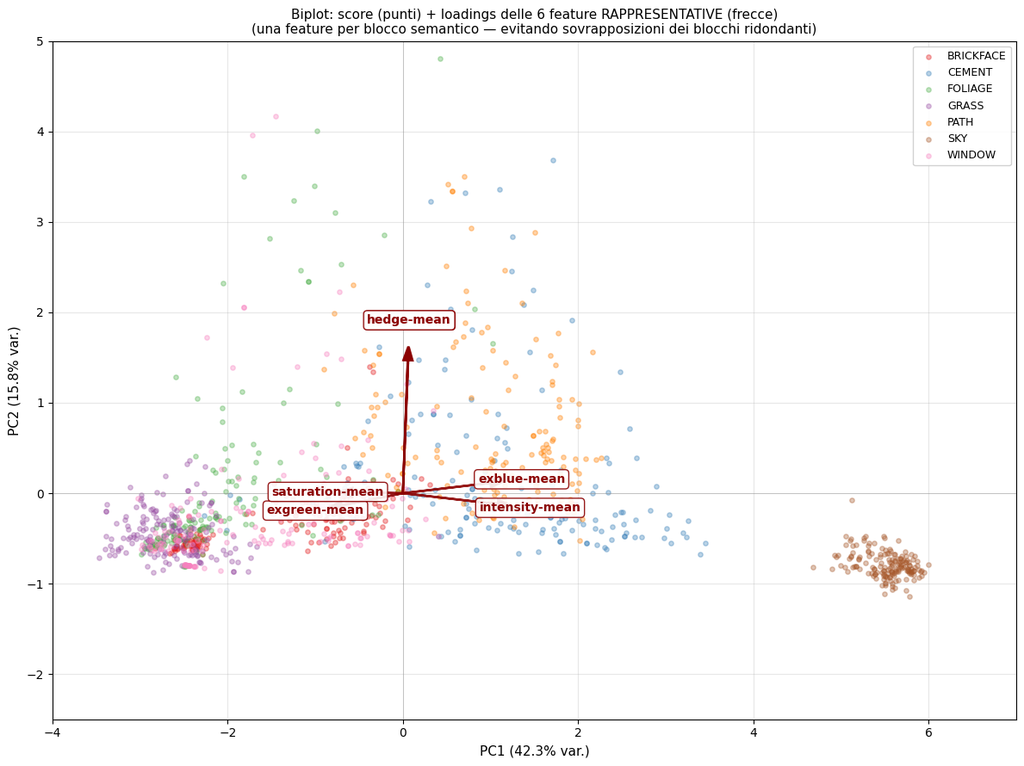

```python
# Feature rappresentative: una per dimensione semantica significativa
representative_features = [
    'intensity-mean',   # blocco luminosita' (PC1 positivo)
    'exblue-mean',      # asse blu (PC1 positivo, leggermente PC2)
    'exgreen-mean',     # asse verde (PC1 negativo)
    'saturation-mean',  # saturazione del colore (PC1 negativo)
    'vedge-mean',       # blocco texture verticale (PC2 positivo)
    'hedge-mean',       # blocco texture orizzontale (PC2 positivo)
]
repr_idx = [feature_names.index(f) for f in representative_features]

print('Feature scelte come rappresentanti per il biplot:')
print(f'{"Feature":20s} {"PC1":>8s} {"PC2":>8s} {"||loading||":>12s}')
print('-' * 52)
for idx in repr_idx:
    norm = np.sqrt(loadings[idx,0]**2 + loadings[idx,1]**2)
    print(f'{feature_names[idx]:20s} {loadings[idx,0]:+8.3f} {loadings[idx,1]:+8.3f} {norm:12.3f}')

# Biplot con etichette distanziate radialmente
fig, ax = plt.subplots(figsize=(12, 9))

# Score plot — punti dei dati con alpha ridotto per far risaltare le frecce
for k, name in enumerate(class_names):
    mask = y_train == k
    ax.scatter(Z_train_pca[mask, 0], Z_train_pca[mask, 1],
               s=15, alpha=0.35, label=name, color=colors7[k])

# Frecce delle feature rappresentative
arrow_scale = 3.5
for idx in repr_idx:
    dx = loadings[idx, 0] * arrow_scale
    dy = loadings[idx, 1] * arrow_scale
    ax.arrow(0, 0, dx, dy,
             head_width=0.10, head_length=0.15,
             fc='darkred', ec='darkred',
             linewidth=1.8, alpha=0.9, length_includes_head=True,
             zorder=10)
    # Etichetta posizionata oltre la punta della freccia
    # con un piccolo offset perpendicolare per evitare sovrapposizioni
    label_x = dx * 1.18
    label_y = dy * 1.18
    ax.text(label_x, label_y, feature_names[idx],
            fontsize=10, color='darkred', ha='center', va='center', weight='bold',
            bbox=dict(facecolor='white', edgecolor='darkred',
                      alpha=0.9, pad=2, boxstyle='round,pad=0.3'),
            zorder=11)

# Assi di riferimento
ax.axhline(0, color='gray', linewidth=0.5, alpha=0.5)
ax.axvline(0, color='gray', linewidth=0.5, alpha=0.5)
ax.set_xlabel(f'PC1 ({pca2.explained_variance_ratio_[0]*100:.1f}% var.)', fontsize=11)
ax.set_ylabel(f'PC2 ({pca2.explained_variance_ratio_[1]*100:.1f}% var.)', fontsize=11)
ax.set_title('Biplot: score (punti) + loadings delle 6 feature RAPPRESENTATIVE (frecce)\n'
             '(una feature per blocco semantico — evitando sovrapposizioni dei blocchi ridondanti)',
             fontsize=11)
ax.set_ylim(-2.5, 5)
ax.set_xlim(-4, 7)
ax.grid(alpha=0.3)
ax.legend(fontsize=9, loc='upper right', framealpha=0.9)
plt.tight_layout()
plt.show()
```

Inoltre il biplot suggerisce:

- **Frecce vicine in direzione** → feature correlate. Es. `intensity-mean` ed `exblue-mean` sono quasi paralleli lungo PC1 → luminosità e blu sono fortemente correlati nel dataset (il cielo è dove entrambe sono alte).
- **Frecce ortogonali** → feature quasi indipendenti. Le frecce di colore (orizzontali sull'asse PC1) e le frecce di texture (verticali sull'asse PC2) sono ortogonali → **colore e texture sono dimensioni indipendenti** in Statlog.
- **Frecce opposte** → feature anti-correlate. `exgreen-mean` è (approssimativamente) opposta a `exblue-mean` → i pixel molto blu tendono a NON essere molto verdi, e viceversa.

### 4.7 Errore di ricostruzione

Proiettando i dati su $k$ componenti principali e ricostruendoli nello spazio originale tramite $\hat{\boldsymbol{x}} = \boldsymbol{V}_k \boldsymbol{V}_k^\top \boldsymbol{x}$, si perde informazione in funzione di $k$. L'errore quadratico medio di ricostruzione $$ \mathrm{MSE}(k) = \frac{1}{N\,n} \sum_{i=1}^N \| \boldsymbol{x}_i - \hat{\boldsymbol{x}}_i \|^2 $$ fornisce una stima quantitativa dell'errore che stiamo commettendo con la compressione.

**Nota importante.** Su dati standardizzati vale l'identità matematica $$ \mathrm{MSE}(k) = 1 - \mathrm{cum}\_\mathrm{var}(k) $$ dove $\mathrm{cum}\_\mathrm{var}(k)$ è la varianza cumulata già mostrata in 4.3. I due grafici sono quindi **speculari** — l'uno cresce da $0$ a $1$, l'altro decresce da $1$ a $0$ — e portano *esattamente la stessa informazione*. Si presenta comunque questa vista in forma di errore perché offre una **prospettiva complementare**: mentre la varianza cumulata dice "quanta informazione stai catturando", l'MSE dice "quanto errore stai commettendo". Le due domande sono equivalenti ma la lettura è più intuitiva a seconda dello scopo.

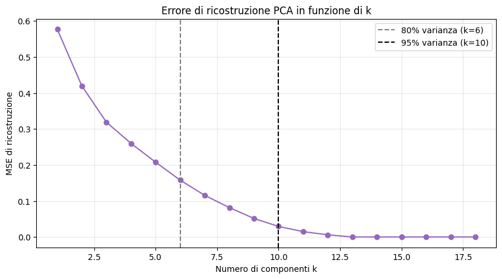

```
   k       MSE    Var. spiegata    Errore residuo
---------------------------------------------------
   2    0.4195           58.0 %            42.0 %
   6    0.1578           84.2 %            15.8 %
  10    0.0293           97.1 %             2.9 %
  12    0.0060           99.4 %             0.6 %
  18    0.0000          100.0 %            -0.0 %
```

```python
# Fit di una PCA con tutte le componenti
pca_full = PCA(n_components=X_train_sc.shape[1])
pca_full.fit(X_train_sc)
cumvar = np.cumsum(pca_full.explained_variance_ratio_)  # cumulata di varianza spiegata

# Errore quadratico medio di ricostruzione per ogni k = 1, ..., n
recon_errors = []
ks = list(range(1, X_train_sc.shape[1] + 1))
for k in ks:
    pca_k = PCA(n_components=k)
    Z = pca_k.fit_transform(X_train_sc)
    X_rec = pca_k.inverse_transform(Z)
    mse = np.mean((X_train_sc - X_rec) ** 2)
    recon_errors.append(mse)

# Grafico dell'errore
fig, ax = plt.subplots(figsize=(10, 5))
ax.plot(ks, recon_errors, marker='o', color='tab:purple')
ax.axvline(n80, ls='--', color='gray', label=f'80% varianza (k={n80})')
ax.axvline(n95, ls='--', color='black', label=f'95% varianza (k={n95})')
ax.set_xlabel('Numero di componenti k')
ax.set_ylabel('MSE di ricostruzione')
ax.set_title('Errore di ricostruzione PCA in funzione di k')
ax.legend(); ax.grid(alpha=0.3)
plt.show()

# Tabella riepilogativa dell'errore per k selezionati (stampata dal codice)
print()
print(f'{"k":>4s}  {"MSE":>8s}  {"Var. spiegata":>15s}  {"Errore residuo":>16s}')
print('-' * 51)
for k in [2, n80, n95, 12, 18]:
    if k > len(recon_errors): continue
    var_spiegata = cumvar[k-1] * 100
    err_res = (1 - cumvar[k-1]) * 100
    print(f'{k:>4d}  {recon_errors[k-1]:>8.4f}  {var_spiegata:>13.1f} %  {err_res:>14.1f} %')
```

## 5. Fisher Discriminant Analysis (FDA)

### 5.1 Descrizione del metodo: Fisher Linear Discriminant (caso binario)

La **Fisher Linear Discriminant** (FLD) cerca una proiezione su una linea in modo che campioni di classi diverse risultino **ben separati** dopo la proiezione. A differenza della PCA — che massimizza la varianza dei dati senza considerare le etichette — la FLD è **supervisionata** e cerca direzioni che soddisfino *due requisiti simultanei*:

1. **massimizzare la separazione tra classi** (le medie proiettate devono essere lontane);
2. **minimizzare la dispersione interna a ogni classe** (i campioni proiettati devono essere concentrati attorno alla propria media).

Supponiamo di avere due classi $C_1$ e $C_2$, e $n$ campioni $\boldsymbol{x}_k \in \mathbb{R}^d$, di cui $n_1$ appartenenti a $C_1$ e $n_2$ a $C_2$. Consideriamo la proiezione lungo una retta di direzione data dal vettore unitario $\boldsymbol{v} \in \mathbb{R}^d$. La proiezione scalare di $\boldsymbol{x}_k$ è $$ \tilde{x}_k = \boldsymbol{v}^\top \boldsymbol{x}_k $$

Definiamo la **media (centroide) della classe $i$** come la media campionaria dei vettori-istanza appartenenti a quella classe: $$ \boldsymbol{\mu}_i = \frac{1}{n_i} \sum_{\boldsymbol{x}_k \in C_i} \boldsymbol{x}_k, \qquad i = 1, 2 $$ che è un vettore in $\mathbb{R}^d$ (vive nello stesso spazio dei dati originali).

Analogamente, la **media delle proiezioni della classe $i$** è la media dei valori scalari $\tilde{x}_k = \boldsymbol{v}^\top \boldsymbol{x}_k$ per i campioni in $C_i$: $$ \tilde{\mu}_i = \frac{1}{n_i} \sum_{\boldsymbol{x}_k \in C_i} \tilde{x}_k = \frac{1}{n_i} \sum_{\boldsymbol{x}_k \in C_i} \boldsymbol{v}^\top \boldsymbol{x}_k = \boldsymbol{v}^\top \left( \frac{1}{n_i} \sum_{\boldsymbol{x}_k \in C_i} \boldsymbol{x}_k \right) = \boldsymbol{v}^\top \boldsymbol{\mu}_i $$

Massimizzare $|\tilde{\mu}_1 - \tilde{\mu}_2|$ è apparentemente sufficiente per garantire una buona separazione delle classi dopo la proiezione, ma **non tiene conto della varianza interna** di ciascuna classe. Possono esistere direzioni con $|\tilde{\mu}_1 - \tilde{\mu}_2|$ grande ma in cui le due classi si sovrappongono pesantemente perché ciascuna ha una dispersione molto ampia. Bisogna quindi **normalizzare** il numeratore con un fattore proporzionale alla dispersione interna delle classi.

#### Scatter e Fisher Criterion (forma iniziale)

Per un insieme di campioni $z_1, \dots, z_n$ di media $\mu_z$, si definisce la **dispersione (scatter)** come $s = \sum_{i=1}^n (z_i - \mu_z)^2$, che è la varianza campionaria moltiplicata per $n$. Definiamo allora le **dispersioni delle proiezioni** delle due classi: $$ \tilde{s}_1^{\,2} = \sum_{\boldsymbol{x}_k \in C_1} (\tilde{x}_k - \tilde{\mu}_1)^2, \qquad \tilde{s}_2^{\,2} = \sum_{\boldsymbol{x}_k \in C_2} (\tilde{x}_k - \tilde{\mu}_2)^2 $$

La **funzione obiettivo di Fisher**, è: $$ J(\boldsymbol{v}) = \frac{(\tilde{\mu}_1 - \tilde{\mu}_2)^2}{\tilde{s}_1^{\,2} + \tilde{s}_2^{\,2}} $$ e il problema della FDA si formula esplicitamente come **massimizzazione rispetto al vettore di proiezione** $\boldsymbol{v}$: $$ \boldsymbol{v}^* = \arg\max_{\boldsymbol{v}\, \in\, \mathbb{R}^d} J(\boldsymbol{v}) $$

#### Matrici di scatter (within e between)

Si definiscono le **scatter matrices** delle singole classi (dispersione del campione originale, *prima* della proiezione): $$ S_i = \sum_{\boldsymbol{x}_k \in C_i} (\boldsymbol{x}_k - \boldsymbol{\mu}_i)(\boldsymbol{x}_k - \boldsymbol{\mu}_i)^\top, \qquad i = 1, 2 $$ Da queste si costruiscono:

- la **within-class scatter matrix** $S_w = S_1 + S_2$, che misura la varianza interna alle classi;
- la **between-class scatter matrix** $S_B = (\boldsymbol{\mu}_1 - \boldsymbol{\mu}_2)(\boldsymbol{\mu}_1 - \boldsymbol{\mu}_2)^\top$, che misura quanto le medie delle classi sono lontane tra loro.

Sostituendo le espressioni delle proiezioni nella funzione obiettivo, si dimostra che: $$ \tilde{s}_1^{\,2} + \tilde{s}_2^{\,2} = \boldsymbol{v}^\top S_w\, \boldsymbol{v}, \qquad (\tilde{\mu}_1 - \tilde{\mu}_2)^2 = \boldsymbol{v}^\top S_B\, \boldsymbol{v} $$

#### Forma finale del Fisher Criterion

Sostituendo numeratore e denominatore nella definizione di $J(\boldsymbol{v})$ otteniamo la **forma compatta**: $$ J(\boldsymbol{v}) = \frac{\boldsymbol{v}^\top S_B\, \boldsymbol{v}}{\boldsymbol{v}^\top S_w\, \boldsymbol{v}} $$ Questo è il **quoziente di Rayleigh generalizzato**. Il problema della FDA si riformula quindi esplicitamente come: $$ \boldsymbol{v}^* = \arg\max_{\boldsymbol{v}\, \in\, \mathbb{R}^d} \frac{\boldsymbol{v}^\top S_B\, \boldsymbol{v}}{\boldsymbol{v}^\top S_w\, \boldsymbol{v}} $$ ovvero: **trovare il vettore $\boldsymbol{v}$ che massimizza il rapporto tra la dispersione tra classi e la dispersione interna alle classi**.

#### Soluzione e direzione discriminante ottima

Derivando $J(\boldsymbol{v})$ rispetto a $\boldsymbol{v}$ e imponendo $\partial J/\partial \boldsymbol{v} = \boldsymbol{0}$, si ottiene il **problema agli autovalori generalizzato**: $$ S_B\, \boldsymbol{v} = \lambda\, S_w\, \boldsymbol{v} $$ Se $S_w$ ha rango massimo (e quindi è invertibile), il problema si riduce a quello standard: $$ S_w^{-1} S_B\, \boldsymbol{v} = \lambda\, \boldsymbol{v} $$

Inoltre, $S_B \boldsymbol{v}$ ha sempre la stessa direzione di $\boldsymbol{\mu}_1 - \boldsymbol{\mu}_2$: $S_B \boldsymbol{v} = (\boldsymbol{\mu}_1 - \boldsymbol{\mu}_2)(\boldsymbol{\mu}_1 - \boldsymbol{\mu}_2)^\top \boldsymbol{v} = \alpha\, (\boldsymbol{\mu}_1 - \boldsymbol{\mu}_2)$ con $\alpha$ scalare. Da qui, la **direzione discriminante ottima** è: $$ \boldsymbol{v} = S_w^{-1} (\boldsymbol{\mu}_1 - \boldsymbol{\mu}_2) $$

#### Verso il caso multiclasse

Nel caso che a noi interessa — Statlog ha **7 classi** — il caso binario sopra non è applicabile direttamente: serve generalizzare a $c \ge 3$ classi. La generalizzazione si chiama **MDA (Multiple Discriminant Analysis)** e la introduciamo subito nella sezione successiva. Dopo torneremo al caso binario nelle sezioni successive per esplorare un *sotto-problema* di 2 classi sul nostro dataset (CEMENT vs WINDOW), in cui potremo applicare la FDA.

### 5.2 MDA — Multiple Discriminant Analysis (generalizzazione multiclasse)

La **Multiple Discriminant Analysis** è la generalizzazione della FLD a problemi con $c \ge 3$ classi. Il metodo proietta i dati, suddivisi in $c$ classi, in un sottospazio di dimensione $m$ con $1 \le m \le c-1$, cercando di **massimizzare la separazione tra le classi**. La scelta di $m$ è un trade-off: $m$ piccolo dà una rappresentazione più compatta ma con meno informazione discriminante; $m = c-1$ tiene tutta l'informazione discriminante possibile (per la nostra applicazione su 7 classi avremo dunque $m \le 6$).

I dati sono proiettati tramite una **matrice di proiezione** $V$: $$ \boldsymbol{y}_i = V^\top \boldsymbol{x}_i, \qquad V \in \mathbb{R}^{n \times m} $$ dove $n$ è la dimensione dei dati originali (per noi $n = 18$), e le colonne di $V$ generano il sottospazio di dimensione $m$ in cui proiettiamo. La proiezione di ciascun dato $\boldsymbol{x}_i$ è il vettore $\boldsymbol{y}_i \in \mathbb{R}^m$. Si definiscono:

- la **media della classe $i$**: $\boldsymbol{\mu}_i = \dfrac{1}{n_i} \sum_{\boldsymbol{x}_k \in \text{classe}\, i} \boldsymbol{x}_k$
- la **media totale** su tutti i campioni: $\boldsymbol{\mu} = \dfrac{1}{n} \sum_{\boldsymbol{x}_k} \boldsymbol{x}_k$

#### Matrici di scatter multiclasse

La **within-class scatter matrix** (somma su tutte le classi delle scatter matrices individuali): $$ S_w = \sum_{i=1}^{c} S_i = \sum_{i=1}^{c} \sum_{\boldsymbol{x}_k \in \text{classe}\, i} (\boldsymbol{x}_k - \boldsymbol{\mu}_i)(\boldsymbol{x}_k - \boldsymbol{\mu}_i)^\top \in \mathbb{R}^{n \times n} $$

La **between-class scatter matrix** ($S_B$ ha rango al più $c-1$): $$ S_B = \sum_{i=1}^{c} n_i\, (\boldsymbol{\mu}_i - \boldsymbol{\mu})(\boldsymbol{\mu}_i - \boldsymbol{\mu})^\top \in \mathbb{R}^{n \times n} $$

#### Funzione obiettivo

Nel caso multiclasse, il quoziente di Rayleigh si generalizza tramite il rapporto dei **determinanti**: $$ J(V) = \frac{\det(V^\top S_B\, V)}{\det(V^\top S_w\, V)} $$ che si massimizza rispetto a $V$.

#### Soluzione

Il problema si riduce ancora al problema agli autovalori generalizzato: $$ S_B\, \boldsymbol{v} = \lambda\, S_w\, \boldsymbol{v} $$ che si riconduce al problema agli autovalori standard: $$ S_w^{-1} S_B\, \boldsymbol{v} = \lambda\, \boldsymbol{v} $$

Il problema ha al più $c-1$ autovalori distinti e non nulli, che si ordinano in modo decrescente: $$ \lambda_1 \ge \lambda_2 \ge \dots \ge \lambda_{c-1} $$ A ciascun autovalore corrisponde un autovettore $\boldsymbol{v}_i$. Gli autovettori $\boldsymbol{v}_1, \dots, \boldsymbol{v}_{c-1}$ rappresentano le **direzioni discriminanti di Fisher**: l'autovettore con autovalore maggiore identifica la direzione di massima discriminazione, e così via in ordine decrescente.

**Per il nostro dataset Statlog (7 classi)**: $c - 1 = 6$ direzioni discriminanti disponibili. Si usa la classe `MultipleFisherDiscriminantAnalysis` (`FisherDA.py`) sviluppata a esercitazione, che implementa esattamente questo algoritmo. Confronteremo la proiezione 2D MDA con quella PCA per visualizzare la differenza tra il criterio supervisionato (Fisher) e quello non supervisionato (PCA).

```
Autovalori MDA (assoluti): [34.2104 16.9519  3.3241  1.8517  0.3781  0.152 ]
```

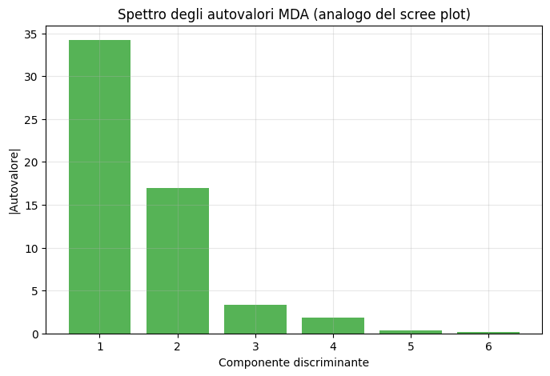

```python
# Tutti i 6 assi discriminanti
mda_full = MDA(n_dimensions=6)
mda_full.fit(X_train_sc, y_train)
eigvals_mda = np.real(mda_full.eigenvalues_)
print('Autovalori MDA (assoluti):', np.abs(eigvals_mda).round(4))

# Scree plot degli autovalori MDA
fig, ax = plt.subplots(figsize=(8, 5))
ax.bar(range(1, len(eigvals_mda)+1), np.abs(eigvals_mda), color='tab:green', alpha=0.8)
ax.set_xlabel('Componente discriminante')
ax.set_ylabel('|Autovalore|')
ax.set_title('Spettro degli autovalori MDA (analogo del scree plot)')
ax.grid(alpha=0.3)
plt.show()
```

**Due osservazioni quantitative:**

Per la classificazione effettiva potremmo decidere di tenere $m = 4$ (i 4 autovalori più grandi catturano > 99% del potere discriminante) per avere un margine di sicurezza, oppure addirittura $m = 2$ se accettiamo di perdere ~10% di discriminabilità in cambio di una rappresentazione bidimensionale immediata.

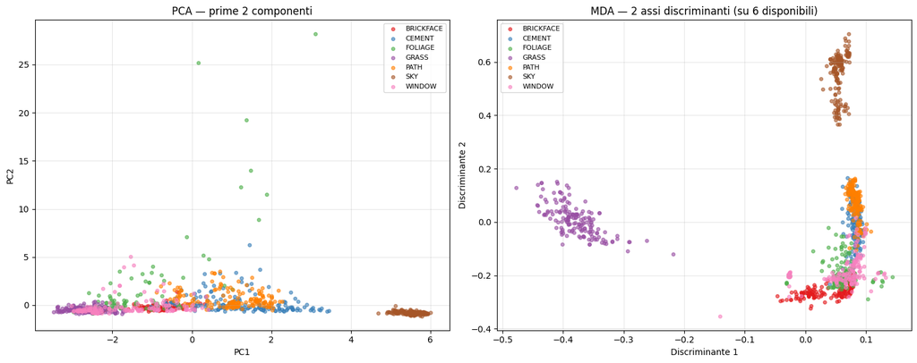

```python
# Proiezione 2D MDA per visualizzazione, accanto al PCA per confronto
mda2 = MDA(n_dimensions=2)
mda2.fit(X_train_sc, y_train)
Z_train_mda = np.real(mda2.transform(X_train_sc))
Z_test_mda  = np.real(mda2.transform(X_test_sc))

fig, axes = plt.subplots(1, 2, figsize=(15, 6))
for k, name in enumerate(class_names):
    mask = y_train == k
    axes[0].scatter(Z_train_pca[mask, 0], Z_train_pca[mask, 1],
                    s=15, alpha=0.6, label=name, color=colors7[k])
    axes[1].scatter(Z_train_mda[mask, 0], Z_train_mda[mask, 1],
                    s=15, alpha=0.6, label=name, color=colors7[k])
axes[0].set_title('PCA — prime 2 componenti'); axes[0].set_xlabel('PC1'); axes[0].set_ylabel('PC2')
axes[0].legend(fontsize=8); axes[0].grid(alpha=0.3)
axes[1].set_title('MDA — 2 assi discriminanti (su 6 disponibili)')
axes[1].set_xlabel('Discriminante 1'); axes[1].set_ylabel('Discriminante 2')
axes[1].legend(fontsize=8); axes[1].grid(alpha=0.3)
plt.tight_layout()
plt.show()
```

Questo confronto è il **risultato chiave** che dimostra empiricamente la differenza tra approccio non supervisionato (PCA) e supervisionato (MDA) sul nostro dataset.

#### Pannello sinistro (PCA — già visto in 4.5)

Solo **`SKY`** è isolato (a destra, PC1 $\approx +5$–$6$). Le altre 6 classi sono **tutte mescolate** nel blocco a sinistra-centro, con `FOLIAGE` che ha gli outlier verticali estremi a PC2 $= 25$. La PCA non sa che vogliamo separare le classi — cerca solo direzioni di varianza massima, che capitano essere principalmente "luminosità" e "texture".

#### Pannello destro (MDA)

La proiezione MDA mostra una struttura **molto più informativa**:

**Due classi isolate in modo netto:**

**Cinque classi ancora sovrapposte:**

#### Predizioni per i classificatori successivi

Basandoci sulla proiezione MDA possiamo prevedere:

- **Classi facili** (`SKY`, `GRASS`): qualunque classificatore raggiungerà accuracy vicine al $100\%$ perché sono cluster ben isolati anche in 2 dimensioni MDA.
- **Classi medio-difficili** (`BRICKFACE`, `PATH`): con qualche direzione MDA in più ($m=3, 4$) diventano separabili. I classificatori supervisionati dovrebbero cavarsela.
- **Classi difficili** (`CEMENT`, `WINDOW`, `FOLIAGE`): sovrapposte anche nello spazio MDA. Serviranno **kernel non lineari** (SVM RBF) o **reti neurali** (MLP) per costruire confini decisionali complessi capaci di separarle.

## 6. Linear Discriminant Analysis (LDA) e Quadratic Discriminant Analysis (QDA)

### 6.1 Verifica di omoschedasticità e sotto-problema binario

#### Esplorazione del sotto-problema binario

Avendo applicato MDA al problema multiclasse principale (7 classi), esploriamo ora un **sotto-problema binario** del nostro dataset, in cui è possibile applicare la FDA.

Scegliamo invece `CEMENT` vs `WINDOW` per due motivi:

#### Nota metodologica sull'uso del validation set

**LDA e QDA non hanno iperparametri da tunare**: la matrice di covarianza è stimata direttamente dai dati, senza scelte discrezionali. Non hanno quindi bisogno di un validation set per selezionare una configurazione. Per questo motivo aggreghiamo **train + validation** e li usiamo insieme per stimare le covarianze — così sfruttiamo tutti i dati disponibili per una stima più stabile.

Questo differisce dal flusso di SVM/MLP, dove il validation set è usato per la **grid search** degli iperparametri. In quel caso il validation set è "occupato" da un ruolo specifico e non può essere aggregato al training. In LDA/QDA il validation è "libero", quindi non c'è motivo di non usarlo.

In tutti i casi, il **test set resta intoccato** fino alla valutazione finale.

### 6.2 LDA e QDA come classificatori bayesiani

La *Linear Discriminant Analysis (LDA)* e la *Quadratic Discriminant Analysis (QDA)* sono tecniche di classificazione supervisionata che si basano su un approccio probabilistico e sul teorema di Bayes. Sia la LDA che la QDA prevedono che i dati delle classi abbiano distribuzione normale $(X \mid Y = k \sim \mathcal{N}(\mu_k, \Sigma))$, con diversa ipotesi sulla matrice di covarianza tra classi.

Dati $x \in \mathbb{R}^n$ e $\mathcal{C} = \{1, \ldots, K\}$ l'insieme delle classi possibili, si vuole stimare la probabilità $P(Y = k \mid X = x)$, dove $Y$ rappresenta la variabile casuale associata alla classe $k \in \mathcal{C}$ e applicando il teorema di Bayes:

$$ P(Y = k \mid X = x) = \frac{P(X = x \mid Y = k) \cdot P(Y = k)}{P(X = x)} = \frac{\pi_k f_k(x)}{\sum_{l=1}^K \pi_l f_l(x)}, $$ dove

- $\pi_k = P(Y = k) \in (0, 1)$, probabilità della classe $k$;
- $f_k(x)$ è la densità condizionata.

Assegniamo $x$ alla classe che massimizza $\pi_k f_k(x)$.

### Linear Discriminant Analysis (LDA)

Nella *Linear Discriminant Analysis* si assume che la matrice di covarianza sia comune a tutte le classi, ovvero $\Sigma_k = \Sigma$ per ogni $k \in \mathcal{C}$. Questa ipotesi prende il nome di *omoschedasticità*. Sotto tale assunzione, la densità condizionata di ciascuna classe assume la forma $$ f_k(x) = \frac{1}{(2\pi)^{n/2} |\Sigma|^{1/2}} \exp\left( -\frac{1}{2}(x - \mu_k)^\top \Sigma^{-1} (x - \mu_k) \right), $$ e la corrispondente *discriminante lineare* si ottiene calcolando il logaritmo di $\pi_k f_k(x)$ ed eliminando i termini indipendenti da $k$, ovvero $$ \delta_k(x) = x^\top \Sigma^{-1} \mu_k - \frac{1}{2} \mu_k^\top \Sigma^{-1} \mu_k + \log \pi_k. $$

Il classificatore associato alla LDA assegna l'osservazione $x$ alla classe $k^*$ per cui $\delta_{k^*}(x)$ è massima. Poiché tale funzione è lineare in $x$, la frontiera di decisione tra due classi qualunque risulta essere un iperpiano: questa proprietà conferisce alla LDA il proprio nome. In pratica, $\Sigma$ viene stimata come media pesata delle covarianze campionarie di ciascuna classe, in modo da utilizzare l'intera popolazione di esempi a disposizione e ridurre la varianza della stima.

### Quadratic Discriminant Analysis (QDA)

La *Quadratic Discriminant Analysis* rilassa l'ipotesi di omoschedasticità, ammettendo che ciascuna classe possieda una propria matrice di covarianza $\Sigma_k$. La densità condizionata diventa $$ f_k(x) = \frac{1}{(2\pi)^{n/2} |\Sigma_k|^{1/2}} \exp\left( -\frac{1}{2}(x - \mu_k)^\top \Sigma_k^{-1} (x - \mu_k) \right), $$ e la corrispondente *discriminante quadratica*, ottenuta nuovamente dal logaritmo di $\pi_k f_k(x)$, è $$ \delta_k(x) = -\frac{1}{2} \log |\Sigma_k| - \frac{1}{2}(x - \mu_k)^\top \Sigma_k^{-1} (x - \mu_k) + \log \pi_k. $$

Diversamente dalla LDA, questa funzione contiene termini quadratici in $x$, e la frontiera di decisione risulta essere una superficie quadratica generale (ellisse, parabola, iperbole). Questa maggiore flessibilità ha un costo in termini di numero di parametri da stimare: se la LDA stima un'unica matrice di covarianza (con circa $n(n+1)/2$ parametri liberi), la QDA ne stima una per ciascuna classe (dunque circa $K \cdot n(n+1)/2$ parametri complessivi). Quando il numero di osservazioni per classe è confrontabile o inferiore al numero di parametri da stimare, la QDA tende a sovra-adattarsi al training set e a generalizzare peggio della LDA.

La scelta tra i due algoritmi rappresenta dunque un classico esempio del **trade-off bias-varianza**: la LDA presenta un bias più elevato dovuto all'ipotesi semplificativa di omoschedasticità, ma una varianza di stima inferiore; la QDA invece presenta un bias minore in quanto rilassa tale ipotesi, ma una varianza maggiore. Quando l'omoschedasticità è approssimativamente verificata o il numero di osservazioni per classe è limitato, la LDA tende a risultare più affidabile; nei casi di eteroschedasticità marcata e con un numero di osservazioni sufficientemente elevato, la QDA può ottenere prestazioni superiori.

Per stabilire in modo informato quale dei due adottare nel sotto-problema in esame, procediamo ora alla verifica numerica dell'ipotesi di omoschedasticità.

```python
# Maschere per il caso binario (CEMENT vs WINDOW) su train, val, test
k_a = list(class_names).index('CEMENT')
k_b = list(class_names).index('WINDOW')

mask_train_bin = np.isin(y_train, [k_a, k_b])
mask_val_bin   = np.isin(y_val,   [k_a, k_b])
mask_test_bin  = np.isin(y_test,  [k_a, k_b])

X_train_bin = X_train_sc[mask_train_bin]
X_val_bin   = X_val_sc[mask_val_bin]
X_test_bin  = X_test_sc[mask_test_bin]
y_train_bin = y_train[mask_train_bin]
y_val_bin   = y_val[mask_val_bin]
y_test_bin  = y_test[mask_test_bin]

# Aggrego train + val
X_trainval_bin = np.vstack([X_train_bin, X_val_bin])
y_trainval_bin = np.hstack([y_train_bin, y_val_bin])

print(f'Dimensioni del sotto-problema binario CEMENT vs WINDOW:')
print(f'  Training:        {X_train_bin.shape[0]:4d} istanze')
print(f'  Validation:      {X_val_bin.shape[0]:4d} istanze')
print(f'  Train + Val:     {X_trainval_bin.shape[0]:4d} istanze (per fittare LDA/QDA)')
print(f'  Test:            {X_test_bin.shape[0]:4d} istanze (per valutazione finale)')
print()

# Matrici di covarianza per classe (calcolate sull'insieme train+val per stima piu' robusta)
cov_a = np.cov(X_trainval_bin[y_trainval_bin == k_a].T)
cov_b = np.cov(X_trainval_bin[y_trainval_bin == k_b].T)

diff_fro = np.linalg.norm(cov_a - cov_b, ord='fro')
avg_fro  = 0.5 * (np.linalg.norm(cov_a, ord='fro') + np.linalg.norm(cov_b, ord='fro'))
rho = diff_fro / avg_fro

print(f'||Cov(CEMENT) - Cov(WINDOW)||_F          = {diff_fro:.4f}')
print(f'Media delle norme F delle due covarianze = {avg_fro:.4f}')
print(f'Rapporto rho                             = {rho:.4f}')
print()
if rho < 0.5:
    print('Ipotesi di omoschedasticita ragionevolmente verificata: LDA giustificata.')
elif rho < 1.0:
    print('Eteroschedasticita moderata: LDA usabile, ma vale la pena confrontare con QDA.')
else:
    print('Forte eteroschedasticita: conviene preferire QDA a LDA.')
```

```
Dimensioni del sotto-problema binario CEMENT vs WINDOW:
  Training:         330 istanze
  Validation:        99 istanze
  Train + Val:      429 istanze (per fittare LDA/QDA)
  Test:             231 istanze (per valutazione finale)

||Cov(CEMENT) - Cov(WINDOW)||_F          = 3.0732
Media delle norme F delle due covarianze = 3.0712
Rapporto rho                             = 1.0006

Forte eteroschedasticita: conviene preferire QDA a LDA.
```

Le matrici di covarianza vengono stimate sull'insieme **train + validation aggregati** (più dati = stima più robusta delle covarianze), e il rapporto $\rho = \frac{\| \Sigma_1 - \Sigma_2 \|_F}{\frac{1}{2}(\|\Sigma_1\|_F + \|\Sigma_2\|_F)}$ misura quanto le due classi differiscono in struttura di dispersione.

Per CEMENT e WINDOW del nostro dataset: le due classi hanno strutture di dispersione abbastanza diverse, e in linea teorica QDA — che ammette covarianze distinte — sarebbe avvantaggiata rispetto a LDA.

### 6.3 LDA binaria — CEMENT vs WINDOW

|  | Train+Val accuracy | Test accuracy |
| --- | --- | --- |
| LDA | 0.9441 | 0.9264 |

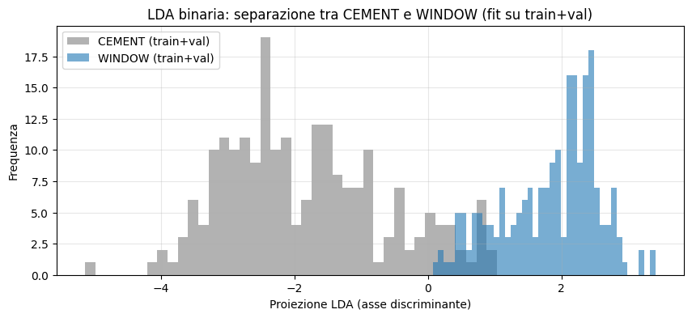

```python
# Fit di LDA su training + validation
lda = LDA(n_components=1)
Z_trainval_lda = lda.fit_transform(X_trainval_bin, y_trainval_bin).flatten()
Z_test_lda     = lda.transform(X_test_bin).flatten()

acc_lda_trainval = lda.score(X_trainval_bin, y_trainval_bin)
acc_lda_test     = lda.score(X_test_bin, y_test_bin)

# Riepilogo in tabella (al posto dei print)
df_lda = pd.DataFrame({
    'Train+Val accuracy': [acc_lda_trainval],
    'Test accuracy':      [acc_lda_test]
}, index=['LDA']).round(4)
display(df_lda)

# Istogramma delle proiezioni LDA (calcolato sul training+validation)
fig, ax = plt.subplots(figsize=(10, 4))
for k, name, color in [(k_a, 'CEMENT', 'tab:gray'),
                        (k_b, 'WINDOW', 'tab:blue')]:
    ax.hist(Z_trainval_lda[y_trainval_bin == k], bins=40, alpha=0.6,
            label=f'{name} (train+val)', color=color)
ax.set_xlabel('Proiezione LDA (asse discriminante)')
ax.set_ylabel('Frequenza')
ax.set_title('LDA binaria: separazione tra CEMENT e WINDOW (fit su train+val)')
ax.legend(); ax.grid(alpha=0.3)
plt.show()
```

**Osservazioni chiave:**

### 6.4 QDA binaria — confronto con LDA

La QDA assume distribuzioni gaussiane con covarianze diverse per classe e produce un discriminante quadratico in $\boldsymbol{x}$ (non più lineare). Confrontiamo le due tecniche sul sotto-problema binario.

|  | Train+Val accuracy | Test accuracy |
| --- | --- | --- |
| LDA | 0.9441 | 0.9264 |
| QDA | 0.9068 | 0.8745 |

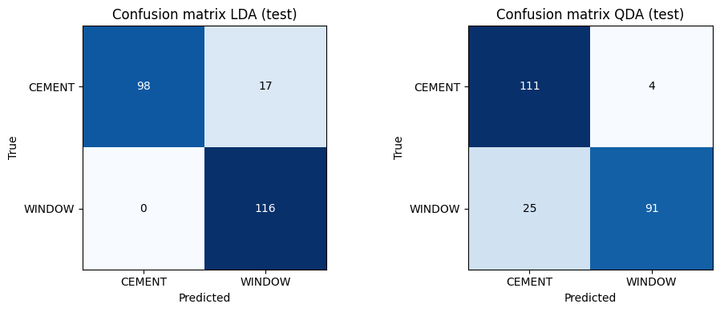

```python
# Fit di QDA su training + validation
qda = QDA()
qda.fit(X_trainval_bin, y_trainval_bin)

acc_qda_trainval = qda.score(X_trainval_bin, y_trainval_bin)
acc_qda_test     = qda.score(X_test_bin, y_test_bin)

df_disc = pd.DataFrame({
    'Train+Val accuracy': [acc_lda_trainval, acc_qda_trainval],
    'Test accuracy':      [acc_lda_test, acc_qda_test]
}, index=['LDA', 'QDA']).round(4)
display(df_disc)

# Confusion matrix LDA vs QDA sul test set
y_pred_lda = lda.predict(X_test_bin)
y_pred_qda = qda.predict(X_test_bin)
cm_lda = confusion_matrix(y_test_bin, y_pred_lda)
cm_qda = confusion_matrix(y_test_bin, y_pred_qda)

fig, axes = plt.subplots(1, 2, figsize=(10, 4))
for ax, cm, title in zip(axes, [cm_lda, cm_qda], ['LDA', 'QDA']):
    ax.imshow(cm, cmap='Blues')
    ax.set_xticks([0, 1]); ax.set_yticks([0, 1])
    ax.set_xticklabels(['CEMENT', 'WINDOW'])
    ax.set_yticklabels(['CEMENT', 'WINDOW'])
    ax.set_title(f'Confusion matrix {title} (test)')
    ax.set_xlabel('Predicted'); ax.set_ylabel('True')
    for i in range(2):
        for j in range(2):
            ax.text(j, i, str(cm[i,j]), ha='center', va='center',
                    color='white' if cm[i,j] > cm.max()/2 else 'black')
plt.tight_layout()
plt.show()
```

I risultati ottenuti presentano un fatto **contro-intuitivo**: la QDA — che ha *più flessibilità* della LDA (confini quadratici invece che lineari) — ottiene accuracy **inferiori** su entrambi gli insiemi.

| Modello | Train + Val | Test | Gap |
| --- | --- | --- | --- |
| **LDA** | $0.9441$ | $0.9264$ | $-0.018$ |
| **QDA** | $0.9068$ | $0.8745$ | $-0.032$ |

La QDA perde **$\sim 5.2$ punti percentuali** sul test rispetto alla LDA: la QDA è più flessibile *nella specifica del modello* (matrici di covarianza diverse per classe), ma questa flessibilità richiede **più parametri da stimare**:

- **QDA** stima **2 matrici di covarianza** $18 \times 18$ (una per `CEMENT`, una per `WINDOW`). Ognuna richiede $\frac{n(n+1)}{2} = 171$ parametri liberi (la matrice è simmetrica) → **342 parametri totali**;
- **LDA** stima **una sola matrice di covarianza** → **171 parametri totali**, la metà.

Disponiamo di $\sim 214$ esempi per classe (train+val = 429 diviso 2), quindi il rapporto **esempi/parametri per singola classe**:

- QDA: $214 / 171 \approx 1.25$ (basso, ai limiti della stimabilità)
- LDA: $429 / 171 \approx 2.5$ (usa tutti gli esempi per stimare la covarianza pooled)

Con un rapporto così basso, la stima delle covarianze individuali di QDA è **rumorosa**, e il rumore si trasferisce in classificazioni errate sul test. LDA, condividendo la covarianza tra le classi, ha una stima molto più stabile.

#### Lettura delle confusion matrix

Sul test set:

### Confronto tra PCA, MDA e LDA

Prima di passare ai modelli non lineari (SVM, MLP), è utile fare il punto sulle tre tecniche viste finora — che condividono l'idea di trovare **direzioni interessanti** nello spazio delle feature ma con obiettivi molto diversi.

| Tecnica | Supervisionata? | Cosa massimizza | Tipo di output | Ruolo nel notebook |
| --- | --- | --- | --- | --- |
| **PCA** | No | Varianza totale dei dati | 18 direzioni ortogonali | Riduzione dimensionale + interpretazione semantica |
| **MDA** | Sì | Rapporto scatter tra-classi / entro-classi | $c - 1 = 6$ direzioni | Diagnosi visiva della separabilità multiclasse |
| **LDA/QDA** | Sì | Posteriore bayesiana $\pi_k f_k(x)$ | Classificatore | Modello generativo con soglia bayesiana |

**PCA — non conosce le classi.** Trova le direzioni di massima varianza del dataset **ignorando le etichette**. Nel nostro caso ha identificato correttamente 3 dimensioni semantiche (luminosità, texture, verde saturo) perché per il dataset Statlog *varianza massima* coincide con *variabilità inter-classe*. Ma questo è **fortunato**, non garantito: se le classi fossero separate lungo una direzione di bassa varianza, la PCA la perderebbe.

**MDA — conosce le classi ma non classifica.** Trova le direzioni che *massimizzano la separazione tra classi*. Nel confronto PCA vs MDA 2D abbiamo visto empiricamente che l'MDA isola **2 classi** (`SKY` + `GRASS`) contro **1 sola** della PCA (`SKY`), su un piano di sole 2 dimensioni. Ma l'MDA è **solo una proiezione**: ti dice come vedere le classi separate, non come classificarle.

**LDA (e QDA) — classifica con un modello probabilistico.** LDA usa la **stessa direzione di Fisher dell'FDA/MDA** ma aggiunge una **soglia di decisione bayesiana** basata sull'assunzione di gaussianità delle classi. QDA rilassa l'ipotesi di omoschedasticità. Nel nostro sotto-problema `CEMENT` vs `WINDOW` abbiamo visto che **LDA batte QDA** ($0.9264$ vs $0.8745$ sul test) — non perché QDA sia peggiore in teoria, ma perché con solo ~215 esempi per classe la stima di 2 matrici di covarianza distinte $18 \times 18$ è troppo rumorosa. È il **compromesso bias-varianza** in una delle sue forme più pulite.

#### Motivazione del passaggio a SVM e MLP

Da qui emergono due indicazioni operative:

- **Kernel SVM (RBF, polinomiale)** — costruiscono confini non lineari mappando implicitamente i dati in uno spazio di dimensione superiore. È l'estensione naturale della LDA/MDA quando le classi non sono separabili linearmente.
- **MLP (rete neurale)** — costruisce confini non lineari **componendo trasformazioni non lineari a più strati**. Ancora più flessibile dell'SVM kernel, ma con più parametri da controllare (rischio di overfitting).

## 7. Support Vector Machine (SVM)

### 7.1 Descrizione del metodo

La **Support Vector Machine (SVM)** è una tecnica di classificazione supervisionata per problemi binari. L'obiettivo è trovare un iperpiano che separi i dati nel miglior modo possibile: in particolare, l'iperpiano che **massimizza il margine** di separazione, con conseguente piccolo rischio di generalizzazione. Diversamente dai classificatori generativi (LDA, QDA), la SVM è un classificatore **discriminativo**: apprende direttamente la frontiera decisionale senza modellare le distribuzioni di probabilità delle classi.

Si considerino i dati di training $S = \{(\boldsymbol{x}_1, y_1), \dots, (\boldsymbol{x}_m, y_m)\}$, con $\boldsymbol{x}_i \in \mathbb{R}^n$ e $y_i \in \{-1, +1\}$. L'iperpiano $\pi_{\boldsymbol{w}, b}$ di $\mathbb{R}^n$ definito dal vettore normale $\boldsymbol{w} \in \mathbb{R}^n$ e dal parametro $b \in \mathbb{R}$ è: $$ \pi_{\boldsymbol{w}, b} = \{ \boldsymbol{x} \in \mathbb{R}^n : \boldsymbol{w}^\top \boldsymbol{x} + b = 0 \} $$ Esso divide lo spazio in due semispazi. Un nuovo dato $\boldsymbol{x}$ viene classificato secondo il segno della funzione $f(\boldsymbol{x}) = \mathrm{sgn}(\boldsymbol{w}^\top \boldsymbol{x} + b)$, e la sua distanza dall'iperpiano è $$ \mathrm{dist}(\pi_{\boldsymbol{w}, b}, \boldsymbol{x}) = \frac{| \boldsymbol{w}^\top \boldsymbol{x} + b |}{\| \boldsymbol{w} \|} $$ Il **margine** dell'iperpiano è la minima distanza tra l'iperpiano stesso e i punti del training set: $$ \rho = \min_{i=1, \dots, m} \frac{| \boldsymbol{w}^\top \boldsymbol{x}_i + b |}{\| \boldsymbol{w} \|} $$

#### Hard margin SVM (caso linearmente separabile)

I dati $\{(\boldsymbol{x}_i, y_i)\}_{i=1}^m$ si dicono **linearmente separabili** se esistono $\boldsymbol{w} \in \mathbb{R}^n$ e $b \in \mathbb{R}$ tali che $y_i (\boldsymbol{w}^\top \boldsymbol{x}_i + b) \ge 1$ per ogni $i = 1, \dots, m$. Sotto questa ipotesi, l'iperpiano ottimo è quello che massimizza il margine $\rho$, ovvero: $$ \rho^* = \max_{\boldsymbol{w}, b \,:\, y_i(\boldsymbol{w}^\top \boldsymbol{x}_i + b) \ge 1} \;\; \min_{i=1, \dots, m} \frac{|\boldsymbol{w}^\top \boldsymbol{x}_i + b|}{\| \boldsymbol{w} \|} $$ Sfruttando il vincolo $y_i(\boldsymbol{w}^\top \boldsymbol{x}_i + b) \ge 1$, il problema si riduce a massimizzare $\frac{1}{\| \boldsymbol{w} \|}$, equivalente a **minimizzare** $\frac{1}{2}\| \boldsymbol{w} \|^2$. Si ottiene quindi il **problema primale di ottimizzazione convessa quadratica**: $$ \min_{\boldsymbol{w}, b} \; \frac{1}{2} \| \boldsymbol{w} \|^2 \qquad \text{s.t.} \quad y_i(\boldsymbol{w}^\top \boldsymbol{x}_i + b) \ge 1, \;\; i = 1, \dots, m $$

#### Lagrangiana e condizioni KKT

Introducendo i moltiplicatori di Lagrange $\alpha_i \ge 0$, la lagrangiana del problema è: $$ L(\boldsymbol{w}, b, \boldsymbol{\alpha}) = \frac{1}{2} \| \boldsymbol{w} \|^2 - \sum_{i=1}^m \alpha_i \left[ y_i(\boldsymbol{w}^\top \boldsymbol{x}_i + b) - 1 \right] $$ Le condizioni di Karush–Kuhn–Tucker (KKT) impongono che il gradiente della lagrangiana sia nullo: $$ \nabla_{\boldsymbol{w}} L = \boldsymbol{w} - \sum_{i=1}^m \alpha_i y_i \boldsymbol{x}_i = \boldsymbol{0} \;\Rightarrow\; \boldsymbol{w} = \sum_{i=1}^m \alpha_i y_i \boldsymbol{x}_i $$ $$ \nabla_b L = -\sum_{i=1}^m \alpha_i y_i = 0 \;\Rightarrow\; \sum_{i=1}^m \alpha_i y_i = 0 $$ $$ \alpha_i \left[ y_i(\boldsymbol{w}^\top \boldsymbol{x}_i + b) - 1 \right] = 0 \qquad \forall i = 1, \dots, m \qquad \text{(complementarità)} $$

#### Support vectors e problema duale

La condizione di complementarità implica che, per ogni $i$, **o** $\alpha_i = 0$ **oppure** $y_i(\boldsymbol{w}^\top \boldsymbol{x}_i + b) = 1$ (il vincolo è attivo). I punti per cui $\alpha_i > 0$ e $y_i(\boldsymbol{w}^\top \boldsymbol{x}_i + b) = 1$ sono detti **support vectors** (vettori di supporto): sono i soli campioni che definiscono $\boldsymbol{w}$, e si trovano esattamente sul margine.

Sostituendo le KKT nella lagrangiana, si ottiene il **problema duale**: $$ \max_{\boldsymbol{\alpha}} \; \sum_{i=1}^m \alpha_i - \frac{1}{2} \sum_{i, j = 1}^m \alpha_i \alpha_j y_i y_j (\boldsymbol{x}_i^\top \boldsymbol{x}_j) \qquad \text{s.t.} \quad \alpha_i \ge 0, \;\; \sum_{i=1}^m \alpha_i y_i = 0 $$ Risolvendo il problema duale si ottiene la soluzione ottimale $\boldsymbol{\alpha}^* = (\alpha_1^*, \dots, \alpha_m^*)$, e l'iperpiano separatore ideale $\pi_{\boldsymbol{w}^*, b^*}$ ha $$ \boldsymbol{w}^* = \sum_{i=1}^m \alpha_i^* y_i \boldsymbol{x}_i, \qquad b^* = y_i - \sum_{j=1}^m \alpha_j^* y_j (\boldsymbol{x}_j^\top \boldsymbol{x}_i) \quad \text{per un qualsiasi support vector } \boldsymbol{x}_i $$ Il classificatore corrispondente è $h(\boldsymbol{x}) = \mathrm{sgn}(\boldsymbol{w}^{*\top} \boldsymbol{x} + b^*)$.

#### Soft margin SVM (caso non linearmente separabile)

Nella pratica due classi non sono quasi mai perfettamente separabili linearmente: a causa di rumore nei dati, può capitare che le classi siano sovrapposte o che esistano dati anomali. Per gestire queste situazioni si introduce una **tolleranza sulla possibilità di oltrepassare il margine**, mediante variabili di slack $\xi_i \ge 0$. Il vincolo originario diventa $$ y_i (\boldsymbol{w}^\top \boldsymbol{x}_i + b) \ge 1 - \xi_i $$ che consente al punto $\boldsymbol{x}_i$ di trovarsi dalla parte sbagliata del margine (o anche dell'iperpiano stesso) pagando una penalità $\xi_i$. Il problema primale diventa: $$ \min_{\boldsymbol{w}, b, \boldsymbol{\xi}} \; \frac{1}{2} \| \boldsymbol{w} \|^2 + C \sum_{i=1}^m \xi_i \qquad \text{s.t.} \quad y_i(\boldsymbol{w}^\top \boldsymbol{x}_i + b) \ge 1 - \xi_i, \;\; \xi_i \ge 0 $$

Il parametro $C > 0$ rappresenta il **trade-off tra minimizzazione del training error e massimizzazione del margine**, ed è un iperparametro di regolarizzazione:

- $C \to 0$ aumenta la *morbidezza* del margine, permettendo ai vettori $\boldsymbol{x}_i$ di superarlo senza grandi penalità (modello con bias maggiore);
- $C \to \infty$ aumenta la *durezza* del margine, riducendo le violazioni ammesse (modello con varianza maggiore, rischio di overfitting).

#### Hinge loss e funzioni di perdita

Il problema primale può essere riscritto equivalentemente come problema non vincolato, sfruttando il fatto che la scelta ottimale per le slack è $\xi_i = \max(0, 1 - y_i(\boldsymbol{w}^\top \boldsymbol{x}_i + b))$: $$ \min_{\boldsymbol{w}, b} \; \frac{1}{2} \| \boldsymbol{w} \|^2 + C \sum_{i=1}^m \left[ 1 - y_i(\boldsymbol{w}^\top \boldsymbol{x}_i + b) \right]_+ $$ dove $[z]_+ = \max(0, z)$. Questa formulazione introduce la **hinge loss**: $$ L_{\mathrm{hinge}}(h(\boldsymbol{x}), y) = \left[ 1 - y \, h(\boldsymbol{x}) \right]_+ $$ (una variante è la **quadratic hinge loss**, $L = ([1 - y h(\boldsymbol{x})]_+)^2$, usata da `LinearSVC` di scikit-learn).

Rispetto alla classica **0-1 loss** (che vale 0 se il dato è classificato correttamente e 1 altrimenti), la hinge loss tiene conto **anche di quanto un dato è vicino al margine**.

La hinge loss è **convessa** e facile da ottimizzare, mentre la 0-1 loss è non continua e non derivabile. La hinge loss costituisce dunque un'**approssimazione superiore** della 0-1 loss che permette un'ottimizzazione efficiente.

#### Problema duale del soft margin

Ripetendo il procedimento di Lagrange con le variabili di slack si arriva al problema duale del soft margin: $$ \max_{\boldsymbol{\alpha}} \; \sum_{i=1}^m \alpha_i - \frac{1}{2} \sum_{i, j = 1}^m \alpha_i \alpha_j y_i y_j (\boldsymbol{x}_i^\top \boldsymbol{x}_j) \qquad \text{s.t.} \quad 0 \le \alpha_i \le C, \;\; \sum_{i=1}^m \alpha_i y_i = 0 $$ L'unica differenza rispetto al caso hard è il **vincolo aggiuntivo** $\alpha_i \le C$, che limita superiormente l'influenza di ciascun support vector. I support vectors del soft margin sono di due tipi: quelli **sul margine** ($0 < \alpha_i < C$, $\xi_i = 0$) e quelli **dentro o oltre il margine** ($\alpha_i = C$, $\xi_i > 0$).

#### Kernel SVM (estensione non lineare)

Quando i dati non sono separabili linearmente nemmeno in modo approssimato, si proiettano in uno spazio di feature di dimensione superiore $\mathcal{H}$ tramite una mappa $\boldsymbol{\phi}: \mathbb{R}^n \to \mathcal{H}$, e si applica la SVM lineare in $\mathcal{H}$. Il punto chiave è che il problema duale dipende dai dati **solo attraverso i prodotti scalari** $\boldsymbol{\phi}(\boldsymbol{x}_i)^\top \boldsymbol{\phi}(\boldsymbol{x}_j)$, che possono essere calcolati direttamente tramite una **funzione kernel**: $$ K(\boldsymbol{x}_i, \boldsymbol{x}_j) = \boldsymbol{\phi}(\boldsymbol{x}_i)^\top \boldsymbol{\phi}(\boldsymbol{x}_j) $$ Questa tecnica è nota come **kernel trick**: permette di lavorare implicitamente in spazi anche infinito-dimensionali senza calcolare esplicitamente $\boldsymbol{\phi}$. I kernel più comuni sono:

- **Kernel lineare**: $K(\boldsymbol{x}, \boldsymbol{x}') = \boldsymbol{x}^\top \boldsymbol{x}'$
- **Kernel polinomiale di grado $d$**: $K(\boldsymbol{x}, \boldsymbol{x}') = (\boldsymbol{x}^\top \boldsymbol{x}' + c_0)^d$
- **Kernel RBF (Gaussiano)**: $K(\boldsymbol{x}, \boldsymbol{x}') = \exp(-\gamma \| \boldsymbol{x} - \boldsymbol{x}' \|^2)$

Il parametro $\gamma$ del kernel RBF controlla la "larghezza" della gaussiana: valori grandi producono confini decisionali molto locali (rischio di overfitting), valori piccoli producono confini più lisci.

#### Estensione multiclasse

La SVM è nativamente binaria, ma può essere estesa a problemi multiclasse attraverso strategie di riduzione:

- **One-vs-Rest** (OvR): si addestra una SVM per ogni classe, contro tutte le altre. Implementata in `LinearSVC` di scikit-learn. Richiede $K$ classificatori per $K$ classi.
- **One-vs-One** (OvO): si addestra una SVM per ogni coppia di classi. Implementata in `SVC` di scikit-learn. Richiede $\binom{K}{2} = K(K-1)/2$ classificatori, ma ciascuno è addestrato su un sotto-problema più piccolo.

Per il nostro dataset Statlog a 7 classi, `LinearSVC` userà 7 classificatori binari, mentre `SVC` (kernel RBF/polinomiale) userà $\binom{7}{2} = 21$ classificatori binari. La predizione finale è ottenuta per votazione (OvO) o massimizzando il margine (OvR).

### 7.2 Test preliminare di separabilità lineare e confronto Hard vs Soft margin

Prima di passare ai kernel verifichiamo se le 7 classi sono linearmente separabili nello spazio originale a 18 dimensioni. Imponendo $C = 10^{10}$ spingiamo la SVM verso il *hard margin*; se i dati sono separabili, l'accuracy sul training sarà $1$. Contemporaneamente confrontiamo diversi valori di $C$ per osservare il trade-off bias-varianza.

```python
C_values = [1e-2, 1e-1, 1.0, 1e2, 1e10]
results = []
for C in C_values:
    model = LinearSVC(C=C, loss='squared_hinge', dual=False, max_iter=10000,
                      random_state=random_state)
    model.fit(X_train_sc, y_train)
    margin_type = 'Hard (C grande)' if C >= 1e6 else ('Soft (forte)' if C <= 0.1 else 'Soft (medio)')
    results.append({
        'C': C, 'Margin': margin_type,
        'Train accuracy': model.score(X_train_sc, y_train),
        'Test accuracy':  model.score(X_test_sc, y_test)
    })
df_C = pd.DataFrame(results)
display(df_C.round(4))

hard_train = df_C.loc[df_C['C']==1e10, 'Train accuracy'].iloc[0]
if hard_train < 1.0:
    print(f'\nAccuracy training con C=1e10 = {hard_train:.4f} < 1: i dati NON sono linearmente separabili.')
    print('Questo motiva l\'uso di SVM con kernel non lineari.')
else:
    print(f'\nAccuracy training con C=1e10 = {hard_train:.4f}: i dati sono linearmente separabili.')
```

|  | C | Margin | Train accuracy | Test accuracy |
| --- | --- | --- | --- | --- |
| 0 | 1.000000e-02 | Soft (forte) | 0.8899 | 0.8504 |
| 1 | 1.000000e-01 | Soft (forte) | 0.9246 | 0.9011 |
| 2 | 1.000000e+00 | Soft (medio) | 0.9246 | 0.9098 |
| 3 | 1.000000e+02 | Soft (medio) | 0.9281 | 0.9159 |
| 4 | 1.000000e+10 | Hard (C grande) | 0.9281 | 0.9172 |

```
Accuracy training con C=1e10 = 0.9281 < 1: i dati NON sono linearmente separabili.
Questo motiva l'uso di SVM con kernel non lineari.
```

Il valore di $C$ ottimale per LinearSVC su questo dataset sembra essere **intorno a $C \in [10^0, 10^{10}]$** con accuracy test praticamente identica. Lo verificheremo nella grid search di §7.7.

**Nota di sintesi.** Con $C = 10^{10}$ (hard margin) osserviamo che l'accuracy sul training è $0.9281 < 1$: i dati di Statlog **non sono perfettamente separabili linearmente** nello spazio originale a 18 dimensioni. Le classi urbane (`BRICKFACE`/`CEMENT`/`WINDOW`) si sovrappongono in modo intrinsecamente non lineare, ed è per questo che useremo il kernel RBF per superare questa sovrapposizione.

### 7.3 SVM lineare con `LinearSVC` (parametri di default)

```python
lsvm = LinearSVC(C=1.0, loss='squared_hinge', dual=False, max_iter=5000,
                  random_state=random_state)
lsvm.fit(X_train_sc, y_train)
y_pred_lsvm = lsvm.predict(X_test_sc)
acc_lsvm = accuracy_score(y_test, y_pred_lsvm)
print(f'Accuracy LinearSVC (test): {acc_lsvm:.4f}')
print('\nClassification report:')
print(classification_report(y_test, y_pred_lsvm, target_names=class_names))
```

```
Accuracy LinearSVC (test): 0.9098

Classification report:
              precision    recall  f1-score   support

   BRICKFACE       0.98      0.98      0.98       115
      CEMENT       0.91      0.81      0.86       115
     FOLIAGE       0.78      0.90      0.83       116
       GRASS       1.00      0.97      0.99       116
        PATH       0.95      1.00      0.97       116
         SKY       1.00      1.00      1.00       115
      WINDOW       0.76      0.71      0.73       116

    accuracy                           0.91       809
   macro avg       0.91      0.91      0.91       809
weighted avg       0.91      0.91      0.91       809
```

**Accuracy test**: $0.91$ — risultato dignitoso, coerente con il valore di $C=1$.

#### Conferma delle predizioni fatte nella MDA

I risultati confermano **letteralmente** ciò che avevamo previsto nel commento alla MDA 2D:

- **`SKY` e `GRASS`** (i due cluster isolati nella proiezione MDA) raggiungono accuracy $\sim 100\%$ → predizione confermata
- **`WINDOW` e `CEMENT`** (le classi più sovrapposte nel blocco urbano) hanno F1 più basso → predizione confermata
- **`FOLIAGE`** ha F1 intermedio per via degli outlier che dominano PC2 → conferma il sospetto

### 7.4 SVM con kernel RBF

```python
svm_rbf = SVC(kernel='rbf', C=1.0, gamma='scale', random_state=random_state)
svm_rbf.fit(X_train_sc, y_train)
y_pred_rbf = svm_rbf.predict(X_test_sc)
acc_rbf = accuracy_score(y_test, y_pred_rbf)
print(f'Accuracy SVC kernel RBF (test): {acc_rbf:.4f}')
print('\nClassification report:')
print(classification_report(y_test, y_pred_rbf, target_names=class_names))
```

```
Accuracy SVC kernel RBF (test): 0.9234

Classification report:
              precision    recall  f1-score   support

   BRICKFACE       0.99      0.97      0.98       115
      CEMENT       0.94      0.85      0.89       115
     FOLIAGE       0.79      0.93      0.85       116
       GRASS       1.00      0.97      0.98       116
        PATH       0.98      1.00      0.99       116
         SKY       1.00      0.99      1.00       115
      WINDOW       0.78      0.75      0.77       116

    accuracy                           0.92       809
   macro avg       0.93      0.92      0.92       809
weighted avg       0.93      0.92      0.92       809
```

**Accuracy test**: $0.92$ — un **miglioramento di $\sim 1.4$ punti percentuali** rispetto a LinearSVC ($0.91$). Il kernel RBF con parametri di default (`C=1`, `gamma='scale'`) sta già producendo un guadagno, sebbene contenuto — vedremo nella grid search di 7.7 che con iperparametri tunati si può fare significativamente meglio.

#### Confronto per classe LinearSVC → SVC RBF

| Classe | F1 LinearSVC | F1 SVC RBF | $\Delta$ |
| --- | --- | --- | --- |
| `SKY` | $1.00$ | $1.00$ | $0$ |
| `GRASS` | $0.99$ | $0.98$ | $-0.01$ |
| `PATH` | $0.97$ | $0.99$ | $+0.02$ |
| `BRICKFACE` | $0.98$ | $0.98$ | $0$ |
| **`CEMENT`** | $0.86$ | $\mathbf{0.89}$ | $\mathbf{+0.03}$ |
| **`FOLIAGE`** | $0.83$ | $\mathbf{0.85}$ | $\mathbf{+0.02}$ |
| **`WINDOW`** | $0.73$ | $\mathbf{0.77}$ | $\mathbf{+0.04}$ |

Le tre classi che erano problematiche per LinearSVC — `WINDOW`, `CEMENT`, `FOLIAGE` — sono esattamente quelle dove l'RBF guadagna di più. Le classi già perfette (`SKY`, `GRASS`, `PATH`, `BRICKFACE`) restano sostanzialmente invariate — non c'è modo di migliorare oltre il $100\%$.

Questo conferma la regola pratica: **quando l'accuracy sul training del hard margin è $< 1$ (nel nostro caso $0.9281$), i kernel non lineari possono migliorare la classificazione**. Il miglioramento con parametri di default è modesto.

### 7.5 SVM con kernel polinomiale

```python
svm_poly = SVC(kernel='poly', degree=3, C=1.0, gamma='scale', random_state=random_state)
svm_poly.fit(X_train_sc, y_train)
y_pred_poly = svm_poly.predict(X_test_sc)
acc_poly = accuracy_score(y_test, y_pred_poly)
print(f'Accuracy SVC kernel polinomiale (deg=3, test): {acc_poly:.4f}')
```

```
Accuracy SVC kernel polinomiale (deg=3, test): 0.8282
```

**Accuracy test**: $0.8282$. Questo risultato è **notevolmente peggio** sia del kernel RBF ($0.9234$) sia del LinearSVC ($0.9098$). Il kernel polinomiale di grado 3 con parametri di default si comporta **peggio di un semplice modello lineare**!

Ci sono delle possibili cause, probabilmente concorrenti:

**1. Grado troppo alto per la struttura dei dati.** Un polinomio di grado 3 implementa un confine decisionale cubico. Se la vera struttura di separazione è approssimativamente lineare (o smooth come quella catturata dal kernel RBF), il polinomio di grado 3 *overfitta* sul training set e generalizza male.

**2. Maggiore sensibilità alla scala.** Il kernel polinomiale è più sensibile alla scala delle feature rispetto all'RBF. Anche se abbiamo standardizzato, residue differenze possono amplificarsi al grado 3.

Questo risultato dimostra che **"più flessibile != meglio"**. In realtà, un modello più flessibile ha più *capacità* di adattarsi ai dati, ma senza tuning appropriato e con parametri di default questa capacità si traduce in **overfitting**. Il kernel polinomiale di grado 3 con default è più flessibile del lineare ma **generalizza peggio**: la lezione è che la flessibilità va **guidata** dagli iperparametri, non presunta come vantaggio automatico.

### 7.6 Verifica empirica del meccanismo multiclasse

Come anticipato,la SVM è nativamente un classificatore *binario* e viene estesa al multiclasse tramite due strategie diverse a seconda dell'implementazione:

- **`LinearSVC`**: usa **One-vs-Rest (OvR)** → addestra $K$ classificatori binari, uno per ogni classe contro tutte le altre. Per Statlog ($K = 7$): **7 classificatori binari**.
- **`SVC` con kernel**: usa **One-vs-One (OvO)** → addestra $\binom{K}{2}$ classificatori binari, uno per ogni coppia di classi. Per Statlog: $\binom{7}{2} = \frac{7 \cdot 6}{2} = $ **21 classificatori binari**.

Verifichiamo empiricamente questo meccanismo ispezionando gli oggetti `lsvm` (LinearSVC) e `svm_rbf` (SVC con kernel RBF) che abbiamo già addestrato.

```python
# === Verifica empirica del meccanismo multiclasse SVM ===
K = len(class_names)  # numero di classi (7)
print(f'Numero di classi: K = {K}')

# LinearSVC usa One-vs-Rest: K classificatori binari
print('\nLinearSVC (One-vs-Rest):')
print(f'  Forma di lsvm.coef_:      {lsvm.coef_.shape}')
print(f'    → {lsvm.coef_.shape[0]} vettori w (uno per ogni classe vs resto)')
print(f'    → ognuno di dimensione {lsvm.coef_.shape[1]} (= n. di feature)')
print(f'  Forma di lsvm.intercept_: {lsvm.intercept_.shape}')
print(f'    → {lsvm.intercept_.shape[0]} bias b (uno per ogni classificatore)')
print(f'  Strategia attesa: {K} classificatori binari (One-vs-Rest)')
print(f'  Strategia osservata: {lsvm.coef_.shape[0]} classificatori → coerente ✓')

# SVC con kernel RBF usa One-vs-One: K(K-1)/2 classificatori binari
n_ovo = K * (K - 1) // 2  # = 21 per K=7
print(f'\nSVC kernel RBF (One-vs-One):')
print(f'  Numero di classi (svm_rbf.classes_):   {len(svm_rbf.classes_)}')
print(f'  Numero atteso di classificatori OvO:    {n_ovo}')
print(f'  Numero di support vector per classe:    {svm_rbf.n_support_}')
print(f'    (totale: {svm_rbf.n_support_.sum()} support vector)')
print(f'  Strategia: {n_ovo} SVM binarie, una per ogni coppia di classi.')

# 3) La forma dell'output di decision_function
print(f'\nForma dell output di decision_function su X_test_sc:')
print(f'  LinearSVC: {lsvm.decision_function(X_test_sc).shape}')
print(f'    → ({X_test_sc.shape[0]} istanze, {K} score, uno per classe)')
print(f'  SVC RBF:   {svm_rbf.decision_function(X_test_sc).shape}')
print(f'    → ({X_test_sc.shape[0]} istanze, {K} score → sklearn aggrega gli OvO con voting)')
```

```
Numero di classi: K = 7

LinearSVC (One-vs-Rest):
  Forma di lsvm.coef_:      (7, 18)
    → 7 vettori w (uno per ogni classe vs resto)
    → ognuno di dimensione 18 (= n. di feature)
  Forma di lsvm.intercept_: (7,)
    → 7 bias b (uno per ogni classificatore)
  Strategia attesa: 7 classificatori binari (One-vs-Rest)
  Strategia osservata: 7 classificatori → coerente ✓

SVC kernel RBF (One-vs-One):
  Numero di classi (svm_rbf.classes_):   7
  Numero atteso di classificatori OvO:    21
  Numero di support vector per classe:    [ 67  82 100  20  53  15 119]
    (totale: 456 support vector)
  Strategia: 21 SVM binarie, una per ogni coppia di classi.

Forma dell output di decision_function su X_test_sc:
  LinearSVC: (809, 7)
    → (809 istanze, 7 score, uno per classe)
  SVC RBF:   (809, 7)
    → (809 istanze, 7 score → sklearn aggrega gli OvO con voting)
```

L'ispezione conferma la teoria:

- **`lsvm.coef_.shape = (7, 18)`**: ci sono **7 vettori $\boldsymbol{w}$**, uno per ciascuno dei 7 classificatori binari della strategia OvR. Ognuno ha dimensione 18 (numero di feature).
- **`svm_rbf.n_support_`**: mostra il numero di support vector per ciascuna delle 7 classi. Internamente la SVC addestra $\binom{7}{2} = 21$ classificatori binari, ma sklearn aggrega i support vector per classe.
- **`decision_function` ha shape $(N, 7)$** per entrambi: anche se SVC RBF internamente usa 21 classificatori OvO, sklearn applica un'aggregazione per produrre uno score per ciascuna classe, in modo che l'interfaccia esterna sia uniforme tra OvR e OvO.

Per la predizione finale, in entrambi i casi sklearn restituisce semplicemente $\arg\max_c$ dello score: si ottiene con `.predict(X)` senza dover sapere se sotto c'è OvR o OvO.

#### Vantaggio computazionale OvR vs OvO

- **OvR** (`LinearSVC`): meno classificatori ($K$ invece di $K(K-1)/2$), ma ogni classificatore lavora sull'intero dataset (tutti gli $N$ esempi). Per $K = 7$: $7$ classificatori su $N = 1155$ esempi → ~8000 "esempi-classificatore" totali.
- **OvO** (`SVC`): più classificatori, ma ognuno lavora solo sui campioni delle 2 classi coinvolte (~$2N/K$ esempi). Per $K = 7$: $21$ classificatori su ~$330$ esempi → ~6900 "esempi-classificatore" totali.

In pratica i due approcci hanno costi computazionali simili e accuratezza comparabile. La scelta tra LinearSVC (OvR) e SVC (OvO) è quindi guidata principalmente dal **tipo di kernel**, non dalla strategia multiclasse.

### 7.7 Ricerca degli iper-parametri — split a 3 vie e k-fold CV

Per selezionare la combinazione ottimale di kernel e iper-parametri ($C$, $\gamma$, grado) adottiamo due strategie complementari:

**A) Split a 3 vie** Usiamo lo split *train/val/test* già definito in 3.2:

- *fit* dei modelli su `X_train_sc` (50% del dataset)
- selezione del migliore in base allo score su `X_val_sc` (15% del dataset)
- valutazione finale del modello selezionato su `X_test_sc` (35%, intoccato fino ad ora)

**B) k-fold cross-validation (sklearn `GridSearchCV`).** Applica internamente una 3-fold CV stratificata sul training set originale, stimando lo score come media sui 3 fold. È più costosa ma con varianza inferiore (lo score finale è meno rumoroso).

Implementiamo entrambe e confrontiamo i risultati.

```python
# Strategia A: usa il validation set
print(f'Dimensioni split a 3 vie:')
print(f'  Training (per il fit):       {X_train_sc.shape[0]}')
print(f'  Validation (per la scelta):  {X_val_sc.shape[0]}')
print(f'  Test (per la valutazione):   {X_test_sc.shape[0]}')

param_list = [
    {'kernel': 'linear', 'C': 0.1},
    {'kernel': 'linear', 'C': 1.0},
    {'kernel': 'linear', 'C': 10.0},
    {'kernel': 'rbf', 'C': 0.1, 'gamma': 'scale'},
    {'kernel': 'rbf', 'C': 1.0, 'gamma': 'scale'},
    {'kernel': 'rbf', 'C': 10.0, 'gamma': 'scale'},
    {'kernel': 'rbf', 'C': 100.0, 'gamma': 'scale'},
    {'kernel': 'rbf', 'C': 1.0, 'gamma': 0.01},
    {'kernel': 'rbf', 'C': 1.0, 'gamma': 0.1},
    {'kernel': 'poly', 'C': 1.0, 'degree': 2, 'gamma': 'scale'},
    {'kernel': 'poly', 'C': 1.0, 'degree': 3, 'gamma': 'scale'},
]
manual_results = []
for params in param_list:
    model = SVC(random_state=random_state, **params)
    model.fit(X_train_sc, y_train)
    f1_val = f1_score(y_val, model.predict(X_val_sc), average='weighted', zero_division=0)
    manual_results.append({**params, 'f1_val': f1_val})
df_manual = pd.DataFrame(manual_results).sort_values('f1_val', ascending=False).reset_index(drop=True)
print('\nRisultati (split a 3 vie, F1 weighted su validation set):')
display(df_manual.head(10))
```

```
Dimensioni split a 3 vie:
  Training (per il fit):       1154
  Validation (per la scelta):  347
  Test (per la valutazione):   809

Risultati (split a 3 vie, F1 weighted su validation set):
```

|  | kernel | C | f1_val | gamma | degree |
| --- | --- | --- | --- | --- | --- |
| 0 | rbf | 100.0 | 0.971252 | scale | NaN |
| 1 | rbf | 10.0 | 0.954344 | scale | NaN |
| 2 | linear | 10.0 | 0.945607 | NaN | NaN |
| 3 | rbf | 1.0 | 0.940029 | 0.1 | NaN |
| 4 | rbf | 1.0 | 0.933880 | scale | NaN |
| 5 | linear | 1.0 | 0.928392 | NaN | NaN |
| 6 | linear | 0.1 | 0.919616 | NaN | NaN |
| 7 | rbf | 1.0 | 0.907687 | 0.01 | NaN |
| 8 | poly | 1.0 | 0.898700 | scale | 2.0 |
| 9 | rbf | 0.1 | 0.874564 | scale | NaN |

Le configurazioni con $C=0.1$ (soft margin forte) e $\gamma=0.01$ (RBF "largo", quasi lineare) sono in fondo perché sotto-adattano. Le configurazioni con $C=100$ rischiano di overfittare ma su Statlog (dataset relativamente piccolo e con confini lisci) restano competitive.

```python
# Strategia B: GridSearchCV con k-fold CV
param_grid_skl = [
    {'kernel': ['linear'], 'C': [0.1, 1, 10]},
    {'kernel': ['rbf'],    'C': [0.1, 1, 10, 100], 'gamma': ['scale', 0.01, 0.1]},
    {'kernel': ['poly'],   'C': [0.1, 1, 10],     'degree': [2, 3], 'gamma': ['scale']}
]
gs = GridSearchCV(estimator=SVC(random_state=random_state),
                  param_grid=param_grid_skl,
                  scoring='f1_weighted',
                  cv=StratifiedKFold(n_splits=3, shuffle=True, random_state=random_state),
                  return_train_score=True,
                  n_jobs=-1,
                  verbose=1)
gs.fit(X_train_sc, y_train)
print('Best params (k-fold CV):', gs.best_params_)
print('Best CV score (f1_weighted):', gs.best_score_)

df_gs = pd.DataFrame(gs.cv_results_)
cols_show = ['params', 'mean_test_score', 'std_test_score', 'mean_train_score', 'rank_test_score']
df_gs_sorted = df_gs[cols_show].sort_values('rank_test_score').reset_index(drop=True)
display(df_gs_sorted.head(10))
```

```
Fitting 3 folds for each of 21 candidates, totalling 63 fits
Best params (k-fold CV): {'C': 100, 'gamma': 0.01, 'kernel': 'rbf'}
Best CV score (f1_weighted): 0.9615110437371203
```

|  | params | mean_test_score | std_test_score | mean_train_score | rank_test_score |
| --- | --- | --- | --- | --- | --- |
| 0 | {'C': 100, 'gamma': 0.01, 'kernel': 'rbf'} | 0.961511 | 0.004632 | 0.977453 | 1 |
| 1 | {'C': 10, 'gamma': 'scale', 'kernel': 'rbf'} | 0.957253 | 0.007776 | 0.978749 | 2 |
| 2 | {'C': 100, 'gamma': 'scale', 'kernel': 'rbf'} | 0.955417 | 0.004109 | 0.989168 | 3 |
| 3 | {'C': 10, 'kernel': 'linear'} | 0.954697 | 0.009258 | 0.968096 | 4 |
| 4 | {'C': 100, 'gamma': 0.1, 'kernel': 'rbf'} | 0.948707 | 0.010491 | 0.994368 | 5 |
| 5 | {'C': 10, 'gamma': 0.1, 'kernel': 'rbf'} | 0.946561 | 0.009172 | 0.983506 | 6 |
| 6 | {'C': 1, 'kernel': 'linear'} | 0.941279 | 0.009391 | 0.956559 | 7 |
| 7 | {'C': 10, 'degree': 2, 'gamma': 'scale', 'kern... | 0.936731 | 0.014975 | 0.963170 | 8 |
| 8 | {'C': 1, 'gamma': 0.1, 'kernel': 'rbf'} | 0.936050 | 0.015215 | 0.958021 | 9 |
| 9 | {'C': 10, 'gamma': 0.01, 'kernel': 'rbf'} | 0.934265 | 0.015454 | 0.947876 | 10 |

```python
best_svm = gs.best_estimator_
y_pred_best = best_svm.predict(X_test_sc)
acc_best = accuracy_score(y_test, y_pred_best)
f1_best  = f1_score(y_test, y_pred_best, average='weighted')
print(f'Best SVM — accuracy test: {acc_best:.4f}')
print(f'Best SVM — f1 weighted test: {f1_best:.4f}')
print('\nClassification report:')
print(classification_report(y_test, y_pred_best, target_names=class_names))
```

```
Best SVM — accuracy test: 0.9468
Best SVM — f1 weighted test: 0.9471

Classification report:
              precision    recall  f1-score   support

   BRICKFACE       1.00      0.97      0.99       115
      CEMENT       0.92      0.88      0.90       115
     FOLIAGE       0.90      0.91      0.90       116
       GRASS       1.00      0.97      0.99       116
        PATH       0.97      1.00      0.99       116
         SKY       1.00      1.00      1.00       115
      WINDOW       0.85      0.90      0.87       116

    accuracy                           0.95       809
   macro avg       0.95      0.95      0.95       809
weighted avg       0.95      0.95      0.95       809
```

La grid search identifica come configurazione ottimale:

$$ \text{Best params} = \{C = 100,\ \gamma = 0.01,\ \text{kernel} = \text{RBF}\} $$

#### Breakdown per classe del Best SVM

| Classe | Precision | Recall | F1 |
| --- | --- | --- | --- |
| `SKY` | $1.00$ | $1.00$ | $1.00$ |
| `BRICKFACE` | $1.00$ | $0.97$ | $0.99$ |
| `PATH` | $0.97$ | $1.00$ | $0.99$ |
| `GRASS` | $1.00$ | $0.97$ | $0.99$ |
| `CEMENT` | $0.92$ | $0.88$ | $0.90$ |
| `FOLIAGE` | $0.90$ | $0.91$ | $0.90$ |
| **`WINDOW`** | $0.85$ | $0.90$ | $\mathbf{0.87}$ |

#### Miglioramenti rispetto al SVC RBF di default (§7.4)

| Classe | F1 default | F1 tunato | $\Delta$ |
| --- | --- | --- | --- |
| `CEMENT` | $0.89$ | $0.90$ | $+0.01$ |
| `FOLIAGE` | $0.85$ | $0.90$ | $\mathbf{+0.05}$ |
| `WINDOW` | $0.77$ | $\mathbf{0.87}$ | $\mathbf{+0.10}$ |

Il tuning ($C=100$ molto più aggressivo del default $C=1$, $\gamma=0.01$ molto più piccolo del default `'scale'`$\approx 0.056$) porta un guadagno di **10 punti su `WINDOW`** e $\sim 5$ su `FOLIAGE`. La lezione è chiara: **il kernel giusto (RBF) non basta, serve anche il tuning dei suoi parametri**. Il regularization $C=100$ permette al modello di essere più aggressivo nel classificare correttamente il training, mentre $\gamma=0.01$ produce un confine decisionale più *liscio* (funzioni gaussiane più larghe) che generalizza meglio.

Questa configurazione è la **stima finale onesta della performance dell'SVM** sul dataset Statlog: $\sim 94.7\%$ di accuracy, con `WINDOW` che finalmente esce dalla soglia di F1 $= 0.73$ del LinearSVC e raggiunge $0.87$.

## 8. Multi-Layer Perceptron (MLP)

### 8.1 Descrizione del metodo

Le **reti neurali** sono una classe di modelli molto flessibili che possono approssimare funzioni complesse, essere addestrate efficientemente e la cui complessità può essere controllata. Le loro applicazioni tipiche sono la **regressione non lineare**, la **classificazione** e la **stima di densità**. Concettualmente, una rete neurale con un hidden layer è un modello di regressione parametrica non lineare la cui capacità rappresentativa è controllabile, e può essere vista come una composizione di funzioni lineari e non lineari.

Il **Multi-Layer Perceptron (MLP)** è la rete neurale *feed-forward fully-connected* più classica: tutti i nodi di un layer sono connessi a tutti i nodi del layer successivo, e l'informazione si propaga in una sola direzione dall'input all'output.

#### Teorema di Kolmogorov (approssimazione universale)

Il fondamento teorico delle reti neurali è il **teorema di Kolmogorov**, che garantisce la loro capacità di rappresentare qualunque funzione continua in alta dimensione. Più precisamente: $$ \text{Ogni funzione continua } g^*: [0,1]^n \to \mathbb{R} \text{ con } n > 1 \text{ può essere scritta come }\;\; g^*(\boldsymbol{x}) = \sum_{q=1}^{2n+1} h_q \!\left( \sum_{p=1}^{n} h_{q,p}(x_p) \right) $$ dove $\{h_q\}, \{h_{q,p}\}$ sono insiemi di funzioni continue $\mathbb{R} \to \mathbb{R}$ che dipendono da $g^*$.

**Interpretazione**: una funzione continua in alta dimensione può sempre essere rappresentata come **composizione di mappe unidimensionali**. Una rete neurale con un input layer ($\ell = 0$), un hidden layer ($\ell = 1$) e un output layer ($\ell = 2$) può quindi rappresentare in linea di principio qualunque $g^*$ continua. Il teorema però **non dice come trovare** le funzioni $h_q$ e $h_{q,p}$: serve un algoritmo di addestramento (vedi più avanti).

#### Struttura a layer e funzioni di attivazione

Una rete neurale è organizzata in **layer**:

- L'**input layer** ($\ell = 0$) ha $n$ elementi $x_i$ corrispondenti alle componenti dell'input $\boldsymbol{x} \in \mathbb{R}^n$.
- L'**hidden layer** ($\ell = 1, \dots, L-1$) ha $n_\ell$ neuroni, ciascuno associato a una coppia di variabili $(\boldsymbol{z}_\ell, \boldsymbol{a}_\ell)$ legate da una *pre-attivazione lineare* e da una *attivazione non lineare*.
- L'**output layer** ($\ell = L$) rappresenta la funzione output $g^*(\boldsymbol{x})$.

Le **funzioni di attivazione** $\tilde{\sigma}: \mathbb{R} \to \mathbb{R}$ introducono la non linearità necessaria a far approssimare funzioni non lineari. Storicamente sono state usate funzioni *smooth* come la **logistica** $\sigma(x) = 1/(1 + e^{-x})$, ma oggi si preferiscono funzioni più semplici dal punto di vista computazionale, che permettono di costruire reti con grande capacità rappresentativa a basso costo. Le più diffuse sono:

| Nome | Espressione | Note |
| --- | --- | --- |
| **Heaviside** (binary step) | $\theta(x) = \mathbb{1}_{[x \ge 0]}$ | Storica, non differenziabile |
| **ReLU** (Rectified Linear Unit) | $R(x) = \max(0, x)$ | La più usata nei modelli moderni |
| **Logistica** (sigmoid) | $\sigma(x) = 1/(1 + e^{-x})$ | Storica, smooth, output in $(0,1)$ |

Un altro modo di aumentare la capacità rappresentativa di una rete è **introdurre più hidden layer** (deep learning).

#### Feed-Forward Neural Networks (forward propagation)

In una rete neurale con $L+1$ layer, l'input layer codifica $\boldsymbol{x}$ e l'output layer codifica la funzione $g^*(\boldsymbol{x})$. Gli altri sono hidden layer. In una rete *feed-forward*, le variabili in ogni layer $\ell$ sono funzione esclusiva delle variabili del layer precedente $\ell - 1$: $$ \boldsymbol{z}_\ell = W_\ell \boldsymbol{a}_{\ell-1} + \boldsymbol{b}_\ell \;\; \leftarrow \text{pre-attivazione} $$ dove $W_\ell \in \mathbb{R}^{n_\ell \times n_{\ell-1}}$ è la **matrice dei pesi** e $\boldsymbol{b}_\ell \in \mathbb{R}^{n_\ell}$ è il **vettore di bias** del layer $\ell$. Si passa al layer successivo applicando l'attivazione: $$ \boldsymbol{a}_\ell = \sigma_\ell(\boldsymbol{z}_\ell) \;\; \leftarrow \text{attivazione} $$ dove $\sigma_\ell: \mathbb{R}^{n_\ell} \to \mathbb{R}^{n_\ell}$ è tipicamente della forma $\sigma_\ell(\boldsymbol{z}) = [\tilde\sigma(z_1), \dots, \tilde\sigma(z_{n_\ell})]^\top$ per $\ell = 1, \dots, L-1$. La funzione di attivazione nell'**output layer** dipende invece dallo scopo della rete (es. softmax per la classificazione, identità per la regressione).

L'output $g^*(\boldsymbol{x})$ è quindi ottenuto dall'input $\boldsymbol{x}$ con una sequenza alternata di mappe lineari $M_\ell(\boldsymbol{a}) = W_\ell \boldsymbol{a} + \boldsymbol{b}_\ell$ e non lineari $\sigma_\ell$: $$ \boldsymbol{x} \;\xrightarrow{M_1}\; \boldsymbol{z}_1 \;\xrightarrow{\sigma_1}\; \boldsymbol{a}_1 \;\xrightarrow{M_2}\; \boldsymbol{z}_2 \;\xrightarrow{\sigma_2}\; \dots \;\xrightarrow{M_L}\; \boldsymbol{z}_L \;\xrightarrow{\sigma_L}\; \boldsymbol{a}_L = g^*(\boldsymbol{x}) $$ Denotando con $\Theta = \{W_\ell, \boldsymbol{b}_\ell\}_{\ell=1}^L$ l'insieme di tutti i pesi e bias, possiamo riassumere: $$ g^*(\boldsymbol{x}; \Theta) = \sigma_L \circ M_L \circ \sigma_{L-1} \circ M_{L-1} \circ \dots \circ \sigma_1 \circ M_1(\boldsymbol{x}) $$ Questo algoritmo è chiamato **feed-forward propagation**.

#### Addestramento: training loss

Una rete neurale è una funzione parametrica $g^*(\boldsymbol{x}; \Theta)$ con dimensione complessiva $\dim(\Theta) = \sum_{\ell=1}^L (n_\ell \cdot n_{\ell-1} + n_\ell)$ (pesi + bias). "Addestrarla" significa trovare il $\hat\Theta$ che minimizza una *training loss* sul training set $\mathcal{T} = \{(\boldsymbol{x}_i, y_i)\}_{i=1}^m$: $$ \hat T_{\mathcal{T}}(g^*(\Theta)) = \frac{1}{m} \sum_{i=1}^m \mathrm{Loss}(\boldsymbol{x}_i, y_i, g^*(\Theta)) = \frac{1}{m} \sum_{i=1}^m C_i(\Theta) $$ Per minimizzarla calcoliamo il gradiente $\nabla_\Theta \hat T_{\mathcal{T}}$, che richiede $\partial C_i / \partial \Theta$ rispetto a *tutti* i parametri (potenzialmente milioni). Serve un metodo efficiente: la **back-propagation**.

#### Back-propagation

La **back-propagation** è l'applicazione sistematica della **regola della catena** a una rete feed-forward, in modo da calcolare i gradienti **strato per strato** dal layer di output indietro fino all'input. Data una coppia $(\boldsymbol{x}, y)$, durante la *forward propagation* si costruiscono i vettori $\boldsymbol{z}_\ell, \boldsymbol{a}_\ell$ per ogni layer e si definisce la matrice diagonale delle derivate di attivazione $\tilde\sigma'(\boldsymbol{z}_\ell) = \mathrm{diag}(\tilde\sigma'(z_{1,\ell}), \dots, \tilde\sigma'(z_{n_\ell, \ell}))$.

**Teorema (Gradiente della training loss).** Data una coppia $(\boldsymbol{x}, y)$, sia $g^*(\Theta)$ l'output della feed-forward propagation e $C(\Theta) = \mathrm{Loss}(y, g^*(\Theta))$ la loss differenziabile. Allora: $$ \frac{\partial C}{\partial W_\ell} = \boldsymbol{\delta}_\ell \boldsymbol{a}_{\ell-1}^\top, \qquad \frac{\partial C}{\partial \boldsymbol{b}_\ell} = \boldsymbol{\delta}_\ell $$ dove $\boldsymbol{\delta}_\ell=\frac{\partial C}{\partial\boldsymbol{z}_L} $ è calcolato **ricorsivamente** per $\ell = L, L-1, \dots, 1$: $$ \boldsymbol{\delta}_L = \tilde\sigma_L'(\boldsymbol{z}_L) \, \frac{\partial C}{\partial \boldsymbol{a}_L} \qquad \text{(inizializzazione all'ultimo strato)} $$ $$ \boldsymbol{\delta}_\ell = \tilde\sigma'(\boldsymbol{z}_\ell) \, W_{\ell+1}^\top \boldsymbol{\delta}_{\ell+1} \qquad \text{(propagazione all'indietro)} $$

**Interpretazione**: l'informazione sull'errore esiste solo nell'ultimo strato (output rispetto all'etichetta vera) e viene trasportata indietro moltiplicando per $W_{\ell+1}^\top$ a ogni passo. È esattamente il fenomeno della *retropropagazione dell'errore*.

#### Steepest Descent

Una volta che sappiamo calcolare $\nabla_\Theta \hat T_{\mathcal{T}}$ via back-propagation, dobbiamo usarlo per addestrare la rete. Il metodo classico è la **discesa del gradiente** (*steepest descent*), basato sull'osservazione che $-\nabla f(\boldsymbol{x})$ è la direzione di più rapida discesa di $f$ nel punto $\boldsymbol{x}$. La formula iterativa è $$ \Theta_{k+1} = \Theta_k - \eta_k \, \nabla_\Theta \hat T_{\mathcal{T}}(\Theta_k) $$ dove $\eta_k > 0$ è il **learning rate** (tasso di addestramento). Sotto ipotesi di regolarità e con scelte opportune di $\eta_k$ il metodo converge a un minimo locale di $\hat T_{\mathcal{T}}$.

**Algoritmo di addestramento (Steepest Descent)**:

1. **Inizializzazione**: genera $\Theta$ a caso e assegnalo alla rete.
2. **Finché non si raggiunge un criterio di arresto** ripeti:
   - Calcola $\nabla_\Theta \hat T_{\mathcal{T}}(\Theta_k)$ via back-propagation
   - Aggiorna i pesi: $\Theta_{k+1} = \Theta_k - \eta_k \nabla_\Theta \hat T_{\mathcal{T}}(\Theta_k)$

Ogni ripetizione del passo 2 è detta **epoca di addestramento**.

**Problema**: per calcolare $\nabla_\Theta \hat T_{\mathcal{T}}$ dobbiamo eseguire una back-propagation per ciascuno degli $m$ campioni del training set e poi mediare. Quando $m$ è molto grande, ogni epoca è computazionalmente costosa.

#### Stochastic Gradient Descent (SGD)

L'idea è introdurre stocasticità nel metodo di ottimizzazione, **approssimando il gradiente esatto con una stima Monte Carlo su un sottoinsieme casuale dei dati**. Definiamo l'aspettativa $$ \hat T_{\mathcal{T}}(g^*(\Theta)) = \frac{1}{m} \sum_{i=1}^m \mathrm{Loss}(\boldsymbol{x}_i, y_i; g^*(\Theta)) = \mathbb{E}_{(x,y) \sim \mathcal{T}}[\mathrm{Loss}(\cdot)] $$ che possiamo approssimare con uno stimatore Monte Carlo su un sottoinsieme $\mathcal{B} \subseteq \mathcal{T}$ detto **mini-batch**: $$ \hat C_{\mathcal{B}}(\Theta) = \frac{1}{|\mathcal{B}|} \sum_{i \in \mathcal{B}} \mathrm{Loss}(\boldsymbol{x}_i, y_i; g^*(\Theta)) $$ La formula iterativa diventa: $$ \Theta_{k+1} = \Theta_k - \eta_k \, \nabla_\Theta \hat C_{\mathcal{B}}(\Theta_k) $$

##### Casi particolari

- **$|\mathcal{B}| = m$ (Full batch)**: ritroviamo lo steepest descent classico ($\hat C_{\mathcal{B}} = \hat T_{\mathcal{T}}$). Aggiornamento per epoca.
- **$|\mathcal{B}| = 1$ (SGD puro)**: a ogni iterazione si prende una sola coppia $(\boldsymbol{x}_i, y_i)$ dal training set e si aggiornano i pesi. **Massima stocasticità**, ogni epoca esegue $m$ aggiornamenti.
- **$1 < |\mathcal{B}| < m$ (Mini-batch SGD)**: il caso intermedio più usato nella pratica. A ogni epoca si genera casualmente una $K$-partizione del training set in mini-batch disgiunti $\mathcal{B}_1, \dots, \mathcal{B}_K$, e si fa un aggiornamento per ciascuno. Buon compromesso tra rumore (utile a sfuggire ai minimi locali) e costo computazionale.

L'ottimizzatore moderno **Adam** (Adaptive Moment Estimation), default in `MLPClassifier` di scikit-learn, è una variante di SGD che adatta dinamicamente il learning rate $\eta_k$ per ogni parametro in base alle stime del primo e secondo momento del gradiente.

#### Criteri di arresto e early stopping

Gli iperparametri di addestramento includono il numero massimo di epoche $E_{\max}$ e la dimensione del mini-batch. Per evitare l'addestramento eccessivo si usano due strategie principali:

- **Numero massimo di epoche** $E_{\max}$: l'addestramento si ferma dopo $E_{\max}$ epoche indipendentemente dalla loss.
- **Early stopping**: si monitora la **loss valutata su un validation set** $\mathcal{V}$ separato dal training. Se la loss su $\mathcal{V}$ non migliora per $N$ epoche consecutive (*pazienza*), l'addestramento si ferma. Serve a impedire di addestrarsi eccessivamente sul training set e cadere in **overfitting**.

L'early stopping richiede quindi di **partizionare il dataset in tre insiemi**: $$ \mathcal{T} \;\; \text{(training, calcola } \hat T_{\mathcal{T}}) \qquad \mathcal{V} \;\; \text{(validation, decide quando fermare)} \qquad \mathcal{P} \;\; \text{(test, valutazione finale)} $$ che è esattamente lo split a 3 vie che abbiamo fatto in 3.2. Nella sezione 8.2 sotto, useremo `MLPClassifier(early_stopping=True, validation_fraction=0.1, n_iter_no_change=20)`.

**Nota metodologica sull'uso del validation set.** `MLPClassifier` di sklearn **non permette di passare esplicitamente un validation set esterno**: se `early_stopping=True`, la libreria prende internamente una frazione (`validation_fraction=0.1`) dal training set che le viene passato.

Il validation set esterno rimane quindi intoccato durante l'addestramento dell'MLP, ma rimane riservato alla **grid search dell'SVM**

#### Riepilogo del flusso completo

1. **Inizializzazione** dei pesi $\Theta$ a caso
2. Per ogni epoca:
   - Per ogni mini-batch $\mathcal{B}_k$:
     - Forward propagation: calcola $g^*(\boldsymbol{x}; \Theta)$ per ogni $\boldsymbol{x} \in \mathcal{B}_k$
     - Calcola la loss $\hat C_{\mathcal{B}_k}(\Theta)$
     - Back-propagation: calcola $\nabla_\Theta \hat C_{\mathcal{B}_k}(\Theta)$
     - Aggiorna i pesi: $\Theta \leftarrow \Theta - \eta \nabla_\Theta \hat C_{\mathcal{B}_k}(\Theta)$
   - Valuta la loss sul validation set $\mathcal{V}$
   - Se non migliora per $N$ epoche consecutive → stop (early stopping)
3. Valutazione finale del modello sui dati di test $\mathcal{P}$

### 8.2 Addestramento del MLP su Statlog

Applichiamo un `MLPClassifier` con architettura $(128, 64)$ hidden unit, attivazione ReLU, ottimizzatore Adam e early stopping. Il validation set per l'early stopping è ricavato internamente dallo scikit-learn dal training set (`validation_fraction=0.1`), quindi non tocchiamo il validation set esterno di §3.2 (che era riservato alla grid search SVM).

```python
mlp = MLPClassifier(hidden_layer_sizes=(128, 64),
                    activation='relu', solver='adam',
                    learning_rate_init=0.001, max_iter=500,
                    early_stopping=True, n_iter_no_change=20,
                    validation_fraction=0.1, batch_size=32,
                    random_state=random_state, verbose=False)
mlp.fit(X_train_sc, y_train)

y_pred_mlp = mlp.predict(X_test_sc)
acc_mlp = accuracy_score(y_test, y_pred_mlp)
f1_mlp  = f1_score(y_test, y_pred_mlp, average='weighted')
print(f'MLP — accuracy test: {acc_mlp:.4f}')
print(f'MLP — f1 weighted test: {f1_mlp:.4f}')
print(f'Iter eseguite: {mlp.n_iter_}')
print('\nClassification report:')
print(classification_report(y_test, y_pred_mlp, target_names=class_names))
```

```
MLP — accuracy test: 0.9629
MLP — f1 weighted test: 0.9633
Iter eseguite: 74

Classification report:
              precision    recall  f1-score   support

   BRICKFACE       1.00      1.00      1.00       115
      CEMENT       0.99      0.87      0.93       115
     FOLIAGE       0.96      0.92      0.94       116
       GRASS       1.00      0.97      0.99       116
        PATH       0.97      1.00      0.99       116
         SKY       1.00      1.00      1.00       115
      WINDOW       0.84      0.97      0.90       116

    accuracy                           0.96       809
   macro avg       0.97      0.96      0.96       809
weighted avg       0.97      0.96      0.96       809
```

**Accuracy test**: $0.9629$ — **il modello migliore di tutta la pipeline**, superiore anche al Best SVM tunato ($0.9468$).

L'MLP a 2 hidden layer $(128, 64)$ ha eseguito **74 iterazioni** prima che l'early stopping intervenisse (validation accuracy stabilizzata per 20 epoche consecutive). Il modello ha $\sim 10\,000$ parametri allenabili contro $\sim 1155$ istanze di training: senza early stopping rischierebbe overfitting, con esso le performance sono robuste e ottime.

L'MLP guadagna significativamente sulle **classi urbane più difficili** (`FOLIAGE`, `CEMENT`, `WINDOW`): $+3$–$+4$ punti F1 sui punti dove il Best SVM aveva ancora margine di miglioramento.

#### Perché l'MLP vince qui

L'MLP a 2 hidden layer implementa una **composizione di trasformazioni non lineari** (ReLU su $128$ unità → ReLU su $64$ unità → softmax su $7$ classi). Questa architettura permette di apprendere **feature intermedie** che il kernel RBF, per quanto flessibile, non può costruire esplicitamente: rappresentazioni gerarchiche in cui il primo strato combina feature originali in "tratti" intermedi (es. "pixel luminoso + alto contrasto verticale" = *bordo di finestra*) e il secondo strato combina i tratti in decisioni di classe.

In questo senso l'MLP non è "solo più flessibile" della SVM RBF, ma ha una **rappresentazione strutturata** che si adatta bene a dataset di feature ingegnerizzate come Statlog, dove esistono blocchi semantici naturali (colore, texture, posizione) che possono essere aggregati in maniera gerarchica.

**Nota importante**: il gap MLP → Best SVM è di $\sim 1.6$ punti percentuali. Su un dataset con 809 esempi di test, l'errore standard sull'accuracy è $\sqrt{0.96 \cdot 0.04 / 809} \approx 0.7\%$, quindi il gap MLP-SVM è al limite della significatività statistica. In pratica: **MLP vince, ma il margine è sottile**. Su dataset con distribuzioni leggermente diverse (o con un altro random seed), il ranking potrebbe invertirsi.

### 8.3 Curva di apprendimento

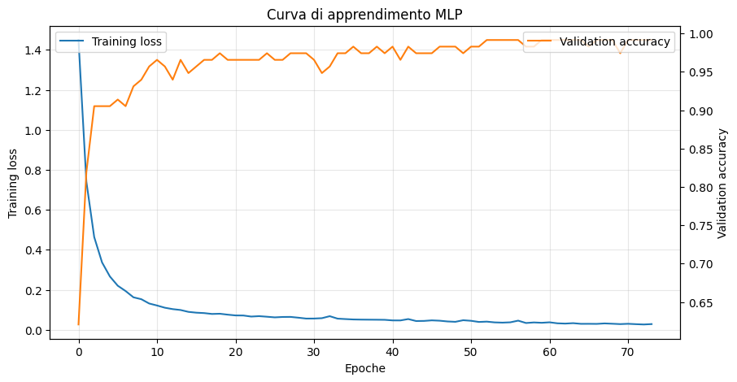

```python
fig, ax = plt.subplots(figsize=(10, 5))
ax.plot(mlp.loss_curve_, label='Training loss')
if hasattr(mlp, 'validation_scores_'):
    ax2 = ax.twinx()
    ax2.plot(mlp.validation_scores_, color='tab:orange', label='Validation accuracy')
    ax2.set_ylabel('Validation accuracy')
    ax2.legend(loc='upper right')
ax.set_xlabel('Epoche'); ax.set_ylabel('Training loss')
ax.set_title('Curva di apprendimento MLP')
ax.legend(loc='upper left'); ax.grid(alpha=0.3)
plt.show()
```

La curva di **training loss** decresce monotonicamente nelle prime epoche, poi rallenta e si stabilizza. La curva di **validation accuracy** (asse di destra) cresce rapidamente, raggiunge un plateau e poi può oscillare leggermente: l'early stopping interviene quando questo plateau è confermato per `n_iter_no_change=20` epoche, evitando epoche inutili.

L'assenza di un "divergere" tra training loss bassa e validation accuracy che cala è un segno positivo: il modello **non sta overfittando** grazie all'early stopping.

## 9. Confronto finale dei modelli

```python
models_results = {
    'LinearSVC':       y_pred_lsvm,
    'SVC (RBF)':       y_pred_rbf,
    'SVC (poly)':      y_pred_poly,
    'SVC (best GS)':   y_pred_best,
    'MLP':             y_pred_mlp,
}
rows = []
for name, y_pred in models_results.items():
    rows.append({
        'Model': name,
        'Accuracy':  accuracy_score(y_test, y_pred),
        'Precision': precision_score(y_test, y_pred, average='weighted', zero_division=0),
        'Recall':    recall_score(y_test, y_pred, average='weighted', zero_division=0),
        'F1':        f1_score(y_test, y_pred, average='weighted', zero_division=0)
    })
df_perf = pd.DataFrame(rows).set_index('Model').round(4)
display(df_perf)
```

| Model | Accuracy | Precision | Recall | F1 |
| --- | --- | --- | --- | --- |
| LinearSVC | 0.9098 | 0.9113 | 0.9098 | 0.9092 |
| SVC (RBF) | 0.9234 | 0.9268 | 0.9234 | 0.9238 |
| SVC (poly) | 0.8282 | 0.8575 | 0.8282 | 0.8303 |
| SVC (best GS) | 0.9468 | 0.9479 | 0.9468 | 0.9471 |
| MLP | 0.9629 | 0.9664 | 0.9629 | 0.9633 |

#### Osservazioni sui gap

- **Gap SVC poly → LinearSVC**: $-8$ punti a sfavore del polinomiale con default. Conferma quanto detto in §7.5: la flessibilità senza tuning è dannosa.
- **Gap LinearSVC → SVC RBF default**: $+1.4$ punti. Beneficio modesto ma reale del kernel non lineare, già con parametri di default.
- **Gap SVC RBF default → SVC best GS**: $+2.3$ punti. Il tuning ($C=100$, $\gamma=0.01$) aggiunge un altro $\sim 2.3\%$: il kernel giusto non basta, serve anche il tuning.
- **Gap SVC best GS → MLP**: $+1.6$ punti a favore dell'MLP. È il gap più "sorprendente": conferma che su questo dataset l'MLP ha un vantaggio strutturale rispetto alla SVM kernel.

#### Interpretazione finale: perché l'MLP vince

Su problemi tabulari di dimensione moderata come Statlog ($n=18$ feature, $N \approx 2300$ esempi) la letteratura suggerisce che SVM kernel e MLP dovrebbero essere **equivalenti**. Il fatto che qui l'MLP vinca (anche se di poco) può essere spiegato da due fattori:

**Considerazione statistica**: con test set di 809 esempi, l'errore standard sulle accuracy è $\sim 0.7\%$, quindi la differenza MLP-SVM ($\sim 1.6\%$) è al confine della significatività ma nella direzione favorevole all'MLP. Su un altro sample il ranking potrebbe invertirsi di poco; il **verdetto qualitativo** ("MLP e Best SVM sono nella stessa fascia $95$–$97\%$, MLP leggermente sopra") resta comunque robusto.

### 9.1 Matrici di confusione 7×7

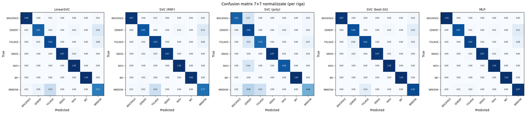

```python
fig, axes = plt.subplots(1, len(models_results), figsize=(24, 5))
for ax, (name, y_pred) in zip(axes, models_results.items()):
    cm = confusion_matrix(y_test, y_pred)
    cm_norm = cm.astype(float) / cm.sum(axis=1, keepdims=True)
    ax.imshow(cm_norm, cmap='Blues', vmin=0, vmax=1)
    ax.set_xticks(range(len(class_names)))
    ax.set_yticks(range(len(class_names)))
    ax.set_xticklabels(class_names, rotation=45, fontsize=7)
    ax.set_yticklabels(class_names, fontsize=7)
    ax.set_title(name, fontsize=10)
    ax.set_xlabel('Predicted'); ax.set_ylabel('True')
    for i in range(cm.shape[0]):
        for j in range(cm.shape[1]):
            ax.text(j, i, f'{cm_norm[i,j]:.2f}', ha='center', va='center',
                    color='white' if cm_norm[i,j] > 0.5 else 'black', fontsize=6)
plt.suptitle('Confusion matrix 7×7 normalizzate (per riga)', fontsize=12)
plt.tight_layout()
plt.show()
```

Lettura: ogni riga è una classe vera, ogni colonna è una classe predetta; i valori sono la frazione delle istanze della classe vera assegnate a ciascuna classe predetta (le righe sommano a 1).

**Diagonale principale**: probabilità di classificazione corretta per ciascuna classe. Valori vicini a $1.00$ (cella scura) = perfetto; valori più bassi = errori frequenti.

#### Progressione visiva tra i modelli

Questa visualizzazione **conferma quantitativamente** l'intuizione qualitativa che avevamo dalla PCA: le classi naturali (`SKY`, `GRASS`, `PATH`, `BRICKFACE`) si distinguono facilmente, le classi urbane (`CEMENT`, `WINDOW`) richiedono modelli più espressivi. L'MLP è il modello che riesce ad addomesticare meglio anche `WINDOW`, la classe che aveva creato più problemi al LinearSVC.

## 10. Conclusioni

Il progetto ha applicato al dataset *Statlog (Image Segmentation)* (UCI #147) l'intera pipeline metodologica del corso.

## Appendice — Formule esplicite

Questa appendice raccoglie le formule per le **metriche di valutazione** dei classificatori (§A) e per alcune **quantità implicite** usate nel notebook (§B), con l'obiettivo di rendere il documento auto-contenuto.

## A — Metriche di valutazione per la classificazione

*Fonte: Lab 05a `nonlinSVM.ipynb` del corso (Della Santa).*

Sia $\mathcal{P}$ il test set e $|\mathcal{P}|$ la sua cardinalità. Per la classificazione multiclasse a $c$ classi $C_1, \dots, C_c$, denotiamo con $A \in \mathbb{N}^{c \times c}$ la **matrice di confusione**, il cui elemento $a_{ij}$ conta i campioni della classe vera $C_i$ predetti come $C_j$.

### A.1 Accuracy

L'*accuracy* è la frazione di predizioni corrette: $$ \mathrm{acc}(\mathcal{P}) = \frac{\text{\# predizioni corrette in } \mathcal{P}}{|\mathcal{P}|} = \frac{\mathrm{tr}(A)}{\sum_{i,j=1}^{c} a_{ij}} $$

**Attenzione**: l'accuracy da sola non è sempre informativa. Su dataset **sbilanciati** un classificatore che restituisce sempre la classe maggioritaria può avere accuracy alta ma essere praticamente inutile. Su Statlog il problema non si pone perché le classi sono perfettamente bilanciate ($330$ esempi ciascuna).

### A.2 Precision e Recall (per classe)

Per la classe $C_i$ (caso multiclasse), rispetto al test set $\mathcal{P}$:

**Precision** (precisione di predizione) — dei campioni **predetti** come $C_i$, quanti sono effettivamente di classe $C_i$: $$ \mathrm{prec}(C_i; \mathcal{P}) = \frac{a_{ii}}{\sum_{k=1}^{c} a_{ki}} = \frac{a_{ii}}{\text{somma della colonna } i} $$

**Recall** (sensibilità di rilevamento) — dei campioni **veri** di classe $C_i$, quanti sono stati identificati correttamente: $$ \mathrm{rec}(C_i; \mathcal{P}) = \frac{a_{ii}}{\sum_{k=1}^{c} a_{ik}} = \frac{a_{ii}}{\text{somma della riga } i} $$

### A.3 $F_\beta$-score

L'$F_\beta$-score aggrega precision e recall in un unico valore in $[0, 1]$: $$ F_\beta(C_i; \mathcal{P}) = (1 + \beta^2) \cdot \frac{\mathrm{prec}(C_i) \cdot \mathrm{rec}(C_i)}{\beta^2 \, \mathrm{prec}(C_i) + \mathrm{rec}(C_i)} $$

Casi particolari:

- $\beta = 1$: $F_1 = 2 \cdot \frac{\mathrm{prec} \cdot \mathrm{rec}}{\mathrm{prec} + \mathrm{rec}}$ (media armonica, il più usato);
- $\beta = 2$: la recall ha peso doppio della precision;
- $\beta = 1/2$: la precision ha peso doppio della recall.

$F_\beta$ vale $1$ nel caso perfetto (precision = recall = 1) e $0$ nel caso più patologico.

### A.4 Medie multiclasse

Nel classification report di `sklearn` si trovano tre righe finali che aggregano le metriche per-classe in un unico numero:

- **macro avg**: media aritmetica semplice delle metriche per classe: $\frac{1}{c} \sum_{i=1}^{c} \mathrm{prec}(C_i)$;
- **weighted avg**: media pesata delle metriche per classe, dove il peso è il supporto (numero di esempi veri) di ciascuna classe;
- **micro avg**: aggregata sui totali di TP/FP/FN considerati globalmente (per Statlog, con classi bilanciate, coincide con l'accuracy).

## B — Formule usate implicitamente nel notebook

### B.1 Standardizzazione (z-score)

In 3.3 abbiamo applicato lo `StandardScaler`, che implementa la trasformazione **z-score** feature-wise: $$ \tilde{x}_{ij} = \frac{x_{ij} - \mu_j}{\sigma_j}, \qquad \mu_j = \frac{1}{N} \sum_{i=1}^{N} x_{ij}, \qquad \sigma_j^2 = \frac{1}{N} \sum_{i=1}^{N} (x_{ij} - \mu_j)^2 $$ dove $\mu_j$ e $\sigma_j$ sono stimati **solo sul training set** e applicati identicamente a train/val/test.

### B.2 Errore di ricostruzione PCA (norma di Frobenius normalizzata)

In 4.7 l'MSE di ricostruzione è: $$ \mathrm{MSE}(k) = \frac{1}{N \cdot n} \sum_{i=1}^{N} \| \boldsymbol{x}_i - \hat{\boldsymbol{x}}_i \|^2 = \frac{1}{N \cdot n} \| X - \hat{X}_k \|_F^2 $$ dove $\hat{X}_k = X V_k V_k^\top$ è la ricostruzione con $k$ componenti principali e $\|\cdot\|_F$ è la norma di Frobenius. La normalizzazione per $N \cdot n$ rende l'errore un valore medio per componente per istanza, indipendente dalla dimensione del dataset.

### B.3 Formula esatta del parametro $\gamma = $ `'scale'` di sklearn

In 7.4 e 7.5 abbiamo usato SVC con `gamma='scale'` (default): $$ \gamma_{\text{scale}} = \frac{1}{n \cdot \mathrm{Var}(X)} $$ dove $n$ è il numero di feature e $\mathrm{Var}(X)$ è la varianza *totale* aggregata su tutte le feature del training. Su dati standardizzati $\mathrm{Var}(X) = 1$ per costruzione, quindi $\gamma_{\text{scale}} = 1/n = 1/18 \approx 0.056$.

### B.4 Formule dei kernel usati

$$ \begin{aligned} K_{\text{lin}}(\boldsymbol{x}, \boldsymbol{x}') &= \boldsymbol{x}^\top \boldsymbol{x}' && \text{(kernel lineare)} \\[2pt] K_{\text{poly}}(\boldsymbol{x}, \boldsymbol{x}') &= (\gamma \boldsymbol{x}^\top \boldsymbol{x}' + c_0)^d && \text{(kernel polinomiale)} \\[2pt] K_{\text{RBF}}(\boldsymbol{x}, \boldsymbol{x}') &= \exp(-\gamma \| \boldsymbol{x} - \boldsymbol{x}' \|^2) && \text{(kernel radiale gaussiano)} \end{aligned} $$

### B.5 Rapporto di eteroschedasticità (§6.1)

$$ \rho = \frac{\| \boldsymbol{\Sigma}_1 - \boldsymbol{\Sigma}_2 \|_F}{\frac{1}{2}\left(\| \boldsymbol{\Sigma}_1 \|_F + \| \boldsymbol{\Sigma}_2 \|_F\right)} $$ dove $\boldsymbol{\Sigma}_1, \boldsymbol{\Sigma}_2$ sono le matrici di covarianza campionarie delle due classi. Valori vicini a $0$ = omoschedasticità; valori vicini o superiori a $1$ = eteroschedasticità forte.

## Bibliografia essenziale

- **Vaccarino, F.** — Materiale didattico del corso di Matematica per l'Intelligenza Artificiale, Politecnico di Torino.
- **Della Santa, F.** — Laboratori del corso di Matematica per l'Intelligenza Artificiale.
- **Vision Group, University of Massachusetts** — *Statlog (Image Segmentation) Data Set*, UCI Machine Learning Repository (1990).